# Pan-Arctic Ocean primary production constrained by turbulent nitrate fluxes

**Achim Randelhoff**¹²*, **Johnna Holding**³⁴, **Markus Janout**⁵, **Mikael Kristian Sejr**³⁴, **Marcel Babin¹²**, **Jean-Éric Tremblay**¹², **Matthew B. Alkire**⁶⁷

¹ Takuvik Joint International Laboratory, Université Laval (QC, Canada) and CNRS (France)

² Département de biologie and Québec-Océan, Université Laval (QC, Canada)

³ Arctic Research Centre, Aarhus University, Ny Munkegade 114, bldg. 1540, 8000 Aarhus C, Denmark

⁴ Department of Bioscience, Aarhus University, Vejlsøvej 25, 8600, Silkeborg, Denmark

⁵ Alfred-Wegener-Institute Helmholtz Center for Polar and Marine Research, Am Handelshafen 12, D-27570 Bremerhaven, Germany

⁶ Applied Physics Laboratory, University of Washington, Seattle, WA USA

⁷ Now at: School of Oceanography, University of Washington, Seattle, WA USA

* **Correspondance**:

Achim Randelhoff, achim.randelhoff@takuvik.ulaval.ca

**Keywords**: Arctic, turbulence, nitrate, flux, primary production, climate change, sea ice

**Abstract**

Arctic Ocean primary productivity is limited by light and inorganic nutrients. With sea ice cover declining in recent decades, nitrate limitation has been speculated to become more prominent. Although much has been learned about nitrate supply from general patterns of ocean circulation and water column stability, a quantitative analysis requires dedicated turbulence measurements that have only started to accumulate in the last dozen years. Here we present new observations of the turbulent vertical nitrate flux in the Laptev Sea, Baffin Bay, and Young Sound (North-East Greenland), supplementing a compilation of 13 published estimates throughout the Arctic Ocean. Combining all flux estimates with a Pan-Arctic database of in situ measurements of nitrate concentration and density, we found the annual nitrate inventory to be largely determined by the strength of stratification and by bathymetry. Nitrate fluxes explained the observed regional patterns and magnitudes of both new primary production and particle export on annual scales. We argue that with few regional exceptions, vertical turbulent nitrate fluxes can be a reliable proxy of Arctic primary production accessible through autonomous and large-scale measurements. They may also provide a framework to assess nutrient limitation scenarios based on clear energetic and mass budget constraints resulting from turbulent mixing and freshwater flows.

# Introduction

Without upward mixing of nutrients, much of the ocean would harbour no life (Ambühl, 1959; Margalef, 1978); the Arctic Ocean is no exception. As dead algae and other particulate matter have the tendency to sink due to their higher density, nutrients are constantly removed from surface waters. Phytoplankton therefore relies on a resupply of nutrients to grow and re-build its standing stock every year. Consequently, primary production, occurring in the euphotic zone where light levels are sufficient to support net growth, is controlled by the vertical flux of new nutrients from below the photic zone each year and thus available to new production, i.e. uptake of allochthonous nitrate (see Appendix and Dugdale and Goering, 1967).

While turbulence is an important factor for aquatic life everywhere, the Arctic Ocean is special in certain regards such as a ubiquitous sea ice cover and strong stratification (Aagaard and Carmack, 1989). Large summertime accumulation of meltwater from sea ice and terrestrial runoff has profound impacts on vertical mixing in the upper ocean (Cole et al., 2018; McPhee and Kantha, 1989; Randelhoff et al., 2017). In winter, brine rejection from freezing ice weakens stratification and creates turbulence (McPhee and Stanton, 1996). We will show throughout this paper that winter mixing is disproportionately important for setting mixed-layer properties.

Sea ice is often assumed to be a rather rigid lid (Padman, 1995) that shuts out a large portion of the sunlight as well as wind energy that could otherwise mix the ocean. With continued decline of sea ice extent and thickness in the 21st century (Comiso, 2012; Meier et al., 2014; Stroeve et al., 2012), the factors limiting Arctic marine growth will likely change. Such a transition in limiting factors usually leads to difficulties in predicting systems (Allen and Hoekstra, 2015). Indeed, Vancoppenolle et al. (2013) found that three different coupled biogeochemical general circulation models and their predictions for integrated Arctic Ocean primary production until the end of this century show diverging trajectories with opposite trends beyond a few decades from now. In their analysis, a prominent uncertainty concerned the evolution of the nitrogen pool in the photic zone. Yet since phytoplankton growth is a rate and not a stock, one should ideally measure the nitrogen flux, not its concentration at a given time, to determine primary production in the long term. Our lack of understanding of the vertical nitrate flux has resulted in the failure to consistently predict future Arctic Ocean primary production.

Stratification inhibits vertical mixing (Osborn, 1980) and consequently vertical turbulent nitrate fluxes. The Arctic Ocean can be divided into a weakly stratified Atlantic sector and a strongly stratified Pacific one (e.g. Carmack, 2007; Bluhm et al., 2015; Tremblay et al., 2015). Vertical turbulent nitrate fluxes are therefore routinely invoked to explain patterns of primary production across the Arctic, such as basin scale differences (Carmack et al., 2006; Randelhoff and Guthrie, 2016; Tremblay et al., 2015), but also an apparently increasing prevalence of fall blooms (Ardyna et al., 2014; Nishino et al., 2015) and even fjord scale differences depending on glacier morphology (Hopwood et al., 2018). These observations are mostly qualitative and rarely quantified with direct measurements. Whereas the vertical nitrate flux in the world ocean has received attention at least since the late 1980s (Lewis et al., 1986), dedicated measurements in the Arctic Ocean have only started to accumulate in the last dozen years. We use this opportunity to summarize the current state of knowledge and investigate the role of vertical turbulent nitrate fluxes in regulating Arctic marine productivity. Interestingly, we find that vertical mixing largely explains marine primary productivity at the pan-Arctic scale. Finally, we outline further research directions to unify physical constraints of Arctic Ocean primary production.

# Material & methods

This study compiles measurements and estimates of the upward vertical turbulent flux of nitrate in different locations across the Arctic Ocean. We present four new estimates of the turbulent vertical nitrate flux, along with a dozen more values derived from the literature. We further supplement the nitrate fluxes with a collection of vertical profiles of seawater nitrate concentration.

## Compilation of NO₃⁻ concentrations

The Pan-Arctic data base carefully compiled by Codispoti et al. (2013) was downloaded from the NOAA website under NODC accession number 0072133. An additional database covered the Canadian Archipelago using various ArcticNet and Department of Fisheries and Oceans Canada cruises, compiled by Coupel et al. (2020, in prep.). We included more winter data, notoriously scarce in the Arctic, by downloading data from the Chukchi shelf as presented by Arrigo et al. (2017). For each profile, we derived (1) the Brunt-Väisälä buoyancy frequency in the depth interval from 30 to 60 m as an indicator of the strength of stratification and (2) the surface nitrate concentration. For the latter, only profiles were used where the depth of the shallowest nitrate measurement was at most 15 m. The shallowest nitrate measurement was then extrapolated to the surface (0 m depth), after which values were averaged over the interval 0-15 m.

## Compilation of turbulent vertical nitrate fluxes

In order to compile previously published estimates of vertical turbulent nitrate fluxes in the Arctic Ocean, we relied mostly on our knowledge of the literature, given the small amount of relevant publications. Additionally, we performed a search on Web of Science (Clarivate Analytics) using the search term `TS=((nitr* AND suppl*) OR (nitr* AND flux*) OR (nitr* AND mix*)) AND TS=((Arctic OR Polar) AND Ocean) AND TS=(vertical OR turbulen*) AND WC=Ocean*`, which resulted in 95 publications that were individually screened for relevance. We only included measurements and estimates based on in-situ observations.

The resulting list comprised just above a dozen flux estimates going back to less than ten publications. To improve data coverage, we present new vertical nitrate flux estimates from the Laptev Sea, Baffin Bay, and Young Sound, as well as a re-calculation of published observations from the Chukchi Sea (Nishino et al., 2015). In order to not disrupt the flow of the main text, details of the respective methods and field campaigns are deferred to the Appendix.

Briefly, our three-week-long summer sampling campaign in Young Sound (a North East Greenland fjord) sought to quantify turbulent mixing, vertical nitrate supply, and new (nitrate-based) production in a fjord strongly stratified by meltwater from the Greenland Ice Sheet. From the Laptev Sea, we present a small selection of representative vertical profiles of nitrate concentrations and oceanic microstructure, collected in the years 2008-2018. From Baffin Bay, we made use of a novel year-long 2017-18 time series of autonomous profilers, so-called biogeochemical (BGC) Argo floats (Biogeochemical-Argo Planning Group, 2016). These were specially adapted in order to function under the ice cover lasting from November to July. Based on the evolution of the upper-ocean nitrate inventory, we inferred the part due to vertical mixing. We further used a data set of nitrate concentrations and turbulent microstructure in the Chukchi Sea (Nishino et al., 2015) to calculate another estimate of vertical nitrate fluxes during early fall.

For the majority of those experiments, turbulence (microstructure) data were measured; just as was the case for the literature values. In some cases, turbulent mixing was inferred from current finestructure; see also the Appendix. Nitrate fluxes were calculated across the nitracline, meaning by combining a nitracline-average turbulent diffusivity with the strength of the nitrate gradient. Individual methodologies may however vary regarding e.g. choice of vertical layer or averaging procedures. According to our personal experience, such choices may make a difference for individual calculations, but less so for large-scale averages, and therefore we take the fluxes recorded in the literature at face value. A systematic assessment of potential methodological errors has to our knowledge however not been conducted. For a more detailed discussion of how vertical nitrate fluxes are measured, and in particular the uncertainties and caveats that come with each method, see the Appendix.

For each of the estimates of the vertical turbulent nitrate flux across the nitracline and into the surface layer, we extracted the end-of-winter surface nitrate concentration either from the same publication or from related studies. We also classified each nitrate flux value as either “perennial stratification” or “winter overturning”. The former means that surface layer stratification persisted year-round; the latter means that the winter mixed layer was significantly deeper than the meltwater-stratified summer surface layer. The classification was done based on perusal of the available literature. The full rationale with a detailed description of the vertical layering in relation to the nitrogen budget is given in the Appendix.

The specific references for each data point are given in the supplementary material. Our entire data set is presented in Table 1; note that it mixes vertical nitrate fluxes across different seasons, vertical levels, regions, and sample sizes.

## Comparison between nitrate fluxes and primary production

We compared nitrate fluxes with new production (primary production based on assimilation of nitrate, see Dugdale and Goering (1967)) and export production. New production estimates were taken from Sakshaug (2004). Export production estimates were taken from Wiedmann (2015), who has compiled the vertical carbon export flux at 200 m depth. To enhance data coverage, we added measurements from two studies from the Central Arctic Ocean (Cai et al., 2010; Honjo et al., 2010). Details can be found in the Supplementary Material.

Both biomass and primary production are frequently given in units of carbon. To convert between units of carbon and nitrate fluxes, we employed a C:N ratio of 6.6 mol C: mol N, the so-called Redfield ratio (Redfield et al., 1963). This particular choice of C:N ratio may be criticized on the grounds that it varies depending on the type of organic matter and other environmental factors (Brzezinski, 1985; Tamelander et al., 2013), and that C:N ratios observed in the Arctic in particular are usually higher (Frigstad et al., 2014). However, turbulence measurements come with a much larger margin of error, with one detailed study giving the systematic bias between two different sets of microstructure probes, signal processing, and calibration procedures as within a factor of 2 (Moum et al., 1995). This is impressive for microstructure measurements but significantly larger than the precision with which the C:N ratio is frequently discussed in biogeochemical contexts. Therefore, by assuming a standard, constant C:N ratio, we make our results easy to adapt to other ratios should the reader want to change this number.

# Results

## Seasonal cycle of surface nitrate concentration

Winter surface nitrate concentrations in the Atlantic sector reached high values around 11 µM (Fig. 1). In the Central Arctic Ocean, concentrations stayed constant at roughly 1-3 µM throughout the year, whereas in the coastal Beaufort Sea they occasionally reached intermediate values in winter. Most regions of the Arctic however became nitrate limited (<1µM) during the summer, with the exception of the Eurasian Basin, the Makarov Basin, and some regions in Southern Fram Strait.

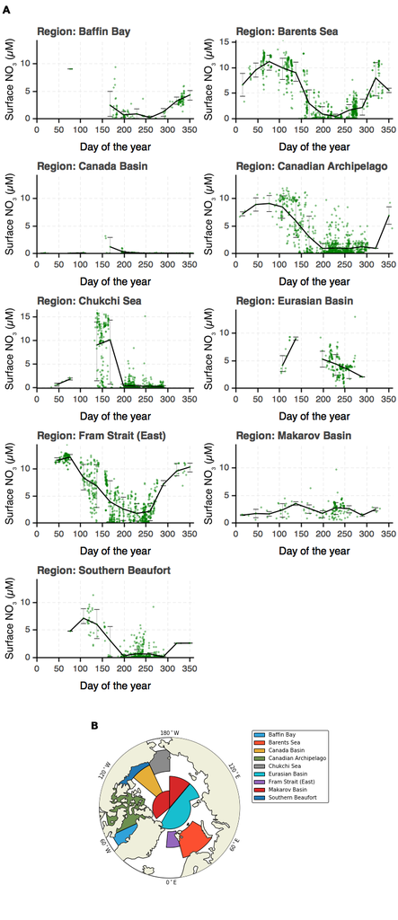

Figure 1: (A) Seasonal cycles of surface nitrate concentrations in different regions of the Arctic. (B) The delineation of these regions largely follows Codispoti et al. (2013) and Peralta-Ferriz and Woodgate (2015).

## Nitrate fluxes

Nitrate flux estimates are still scarce given that they require co-located measurements of both turbulence and nitrate concentrations; however, they approach Pan-Arctic coverage (Fig. 2). Highest values (> 1 mmol N m⁻² d⁻¹) were found in the Atlantic sector. The lowest values (<< 0.1 mmol N m⁻² d⁻¹) occurred in the central basins (Canada Basin) and in Young Sound and the Laptev Sea, two locations strongly impacted by terrestrial freshwater.

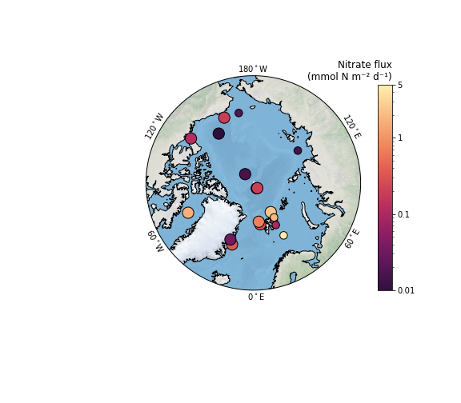

Figure 2: All nitrate fluxes across the Arctic Ocean compiled for this study, irrespective of season and vertical levels. The smaller dots indicate single stations, whereas the big dots represent averages over larger time or space scales.

## Nitrate flux seasonality

The seasonal cycle of surface nitrate concentration was also reflected in its upward fluxes (Fig. 3). In areas where the water column overturned in winter, summer fluxes were an order of magnitude below winter values. A notable exception was observed at one station in the Barents Sea south of the polar front (Wiedmann et al., 2017), where the water was weakly stratified even in summer and hence nitrate fluxes were probably at least as high as in winter with 5 mmol N m⁻² d⁻¹ (Table 1), although sample size (N=1) was not sufficient to draw further conclusions.

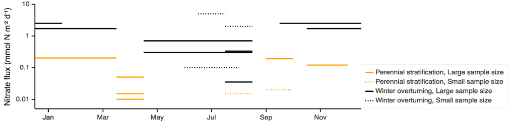

Figure 3: Vertical turbulent nitrate fluxes as a function of the month. Black lines mark the regions where the water column overturns in winter and orange those where it does not. Dotted lines reflect flux estimates based on small sample sizes (N), potentially not very representative of the regional or seasonal scale, whereas solid lines indicate data that are representative of a larger spatial or temporal scale.

Observations over a full seasonal cycle were only available in areas where the water column overturns, notably in the Barents sea and shelf slope area (Table 1). In contrast, in the non-overturning regions, fluxes were lower overall, but there is not enough data to test whether the seasonality itself is, in relative terms, really much weaker there.

# Discussion

## Nitrate fluxes as a function of stratification and seasonality

The vertical nitrate flux (F$_N$) in winter was remarkably well correlated with the pre-bloom nitrate surface concentration [NO$_3^-$]$_0$ (Fig. 4A). A linear model [NO$_3^-$]$_0$ = 7.6µM + 3.4µM$\cdot$log$_{10}$(F$_N$/mmol N m⁻² d⁻¹) yielded an adjusted $R^2$=0.85 and p=0.002 for the linear coefficient. Consequently, deep winter mixing, where it occurs, likely is a controlling factor of the annual nitrate inventory, expanding on direct measurements of a full annual cycle over the Barents Sea shelf break (Randelhoff et al., 2015). Our results quantitatively support the perception that vertical nitrate fluxes explain the seasonality of the upper ocean nitrate inventory, as has been surmised multiple times in the literature (see e.g. Carmack and Wassmann, 2006; Tremblay et al., 2015) based on general considerations of stratification and bathymetry.

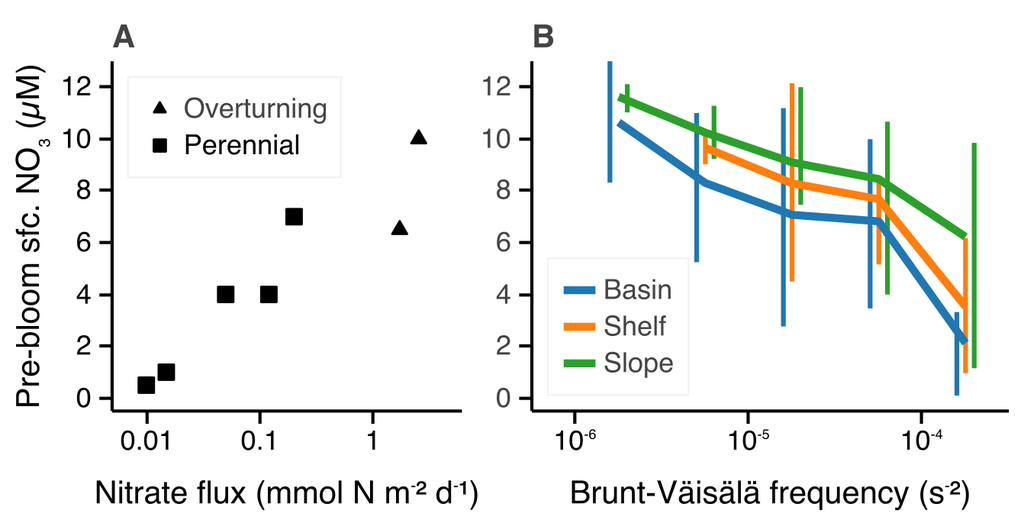

Figure 4: The surface nitrate inventory dominated by variations in turbulent mixing. The annual pre-bloom surface nitrate concentration graphed as a function of (A) the vertical nitrate flux during winter and (B) the strength of water column stratification in the upper 30-60 m depth interval. The bold curves show average nitrate concentration for a given strength of stratification for either of three bathymetry types. Vertical bars (horizontally slightly offset to increase readability) indicate the standard deviation of data for each bin. Data sources: (A) nitrate flux compilation, (B) nitrate profile database.

Stratification and bathymetry also governed pre-bloom surface nitrate concentrations (Fig. 4B) and, by extension from the aforementioned, vertical nitrate fluxes. Stratification represents the resistance of the water column against overturning and vertical mixing, making its link to vertical nitrate fluxes explicit. As for bathymetry, locations with the same strength of upper-ocean stratification had on average consistently highest pre-bloom nitrate over the shelf slope (200 m < depth < 1500 m), lower on the shelves (< 200 m), and lowest over the basins (>1500 m). These findings correspond to general expectations as rough or shallow topography lets currents interact with the bathymetry. Mixing in the Arctic has indeed been found to be especially elevated over the shelf slope (Rippeth et al., 2015). Tidal velocities are generally higher over the shelves than over the deep basins (Kowalik and Proshutinsky, 2013). The Arctic boundary current close to the shelf break may also provide opportunities for localized upwelling through interaction with topography or wind (Carmack and Chapman, 2003; Kämpf and Chapman, 2016).

## Primary production constrained by nitrate fluxes

### Annual basin-scale productivity

Nitrate supply should constrain primary production. Regenerated production is a large if not dominant fraction of primary production where nitrogen is scarce and is therefore not directly related to nitrate fluxes, unlike new production, which relies on nitrate brought up from below the photic zone (Dugdale and Goering, 1967). In the absence of significant advection, new production is even stipulated to be similar to the upward nitrate flux based on conservation of mass alone (see Appendix, Fig. 5).

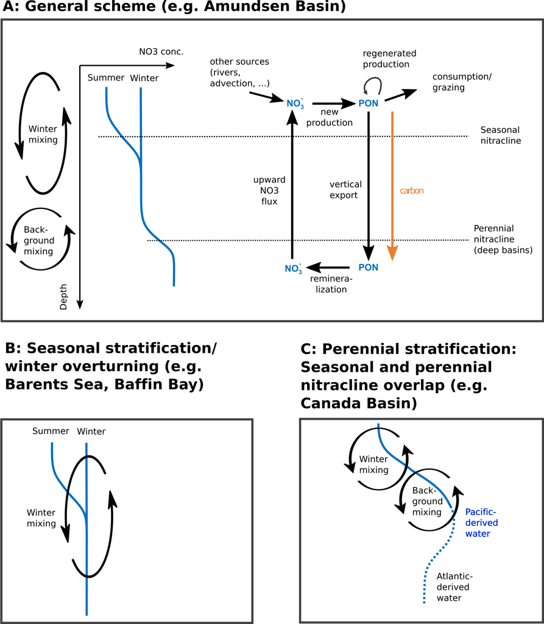

Figure 5: A simplified marine nitrogen cycle and idealized Arctic hydrography. (A) General schematic of a vertical profile of nitrate concentration, along with the respective portion of the nitrogen cycle that takes place in each layer. In this idealized case, there is a clear separation between the seasonal variations in nitrate concentrations in the surface layer which give rise to the seasonal nitracline, and the underlying perennial nitracline. (B) In areas with deep overturning into the waters of maximum nitrate concentration, the deep nitracline ceases to be meaningful. Instead, nitrate fluxes tap into high-nutrient water every winter. (C) Highly stratified areas do not see large seasonal excursions in surface layer nitrate concentrations or mixing depths.

On annual time scales, both the upward nitrate flux in winter into the surface mixed layer, the particle export at 200 m depth, and new production (nitrate uptake) matched up reasonably well for Baffin Bay, the Barents Sea, the Southern Beaufort Sea, and the Central basin (Fig. 6), both in regional patterns and order of magnitude. (Other regions lack estimates of the winter nitrate flux.) Indeed, annual budgets have to be closed if nitrate inventories are not to change in the long term. The relatively minor differences between export production, new production, and the vertical nitrate flux may reflect the extreme disparity of spatial and temporal scales of the different measurements. However, no study has systematically investigated all three quantities on annual to interannual time scales and at the same location.

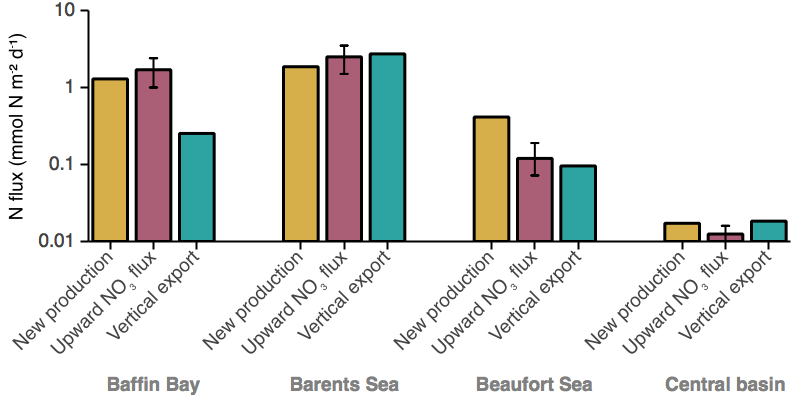

Figure 6: Annual nitrogen fluxes in the Arctic surface ocean. Winter average upward nitrate flux, new production, and vertical downward particle export (converted to nitrogen units using the Redfield ratio) at 200 m depth compared across four regions of the Arctic Ocean. Data sources: Nitrate fluxes, see Table 1; new production, Sakshaug (2004); export production, Wiedmann (2015), Honjo et al. (2010), and Cai et al. (2010). Error bars were systematically only available for nitrate fluxes.

### Short-term new production

A different matter is whether or not during summer, upward mixing of nitrate limits the amount of new production in the short term. Here, the published literature gives a less clear picture (Fig. 7A). Randelhoff et al. (2016) measured vertical nitrate flux and new production for both spring and summer in the marginal ice zone around northern Fram Strait. In spring, new production was considerably larger than vertical nitrate supply as nitrate was not yet depleted and hence did not limit photosynthesis. In summer, on the other hand, when the surface water was nitrate-depleted, new production was an order of magnitude *smaller* than nitrate supply, contrary to the hypothesis.

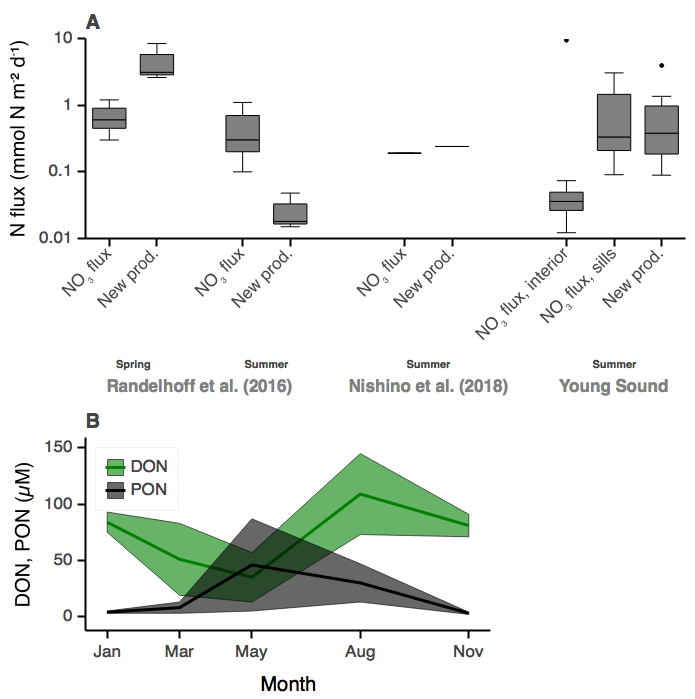

A likely contribution to this discrepancy was the seasonal buildup of dissolved organic nitrogen (Fig. 7B) observed during the same field campaigns by Paulsen et al. (2018). The nitrate uptake rate measurements by Randelhoff et al. (2016) only considered assimilation into the particulate pool due to methodological constraints. The simultaneous production of dissolved organic nitrogen could have diverted nitrate from the particulate to the dissolved production. However, even if there were an imbalance between supply and uptake of nitrate, the associated change in the nitrate concentration would be slow and necessitate Lagrangian measurements over weeks to detect them. Recycling of nitrogen in the microbial loop may turn out to be important when balancing nutrient fluxes with new production over short subseasonal time scales. Nishino et al. (2018) found good agreement between upward nitrate flux, nitrate uptake, and export of particulate organic matter, based on a case study in the Chukchi sea. This may represent geographic differences in the dynamics of the system, or even in the methodology. Nishino et al. (2018) used different methods from those of Randelhoff et al. (2016), even though they neglected assimilation into the dissolved nitrogen pool as well (Shiozaki et al., 2009).

Our measurements in Young Sound, North-East Greenland (see Appendix), gave a diametrically opposed perspective: Here, vertically integrated new production was significantly above the vertical turbulent supply of new nitrate in this extremely quiescent fjord. Overall productivity in Young Sound is therefore likely limited by strong stratification and weak vertical mixing (Holding et al., 2019). Tidal mixing over the two shallow sills in concert with isopycnal mixing may contribute to overall upward nitrate supply (see e.g. Fer and Drinkwater, 2014), but terrestrial runoff may also contribute significantly to the nutrient cycling (Rysgaard et al., 2003) as nitrate concentrations in run-off water are higher than those measured in the sea surface (Paulsen et al., 2017). This scenario is likely specific to this fjord and cannot be generalized around Greenland as nitrate concentrations in Greenland Ice Sheet run-off often act to dilute surface nitrate concentrations (Hopwood et al., 2019; Meire et al., 2016).

In the same vein, but outside the Arctic Ocean, Law et al. (2001) and Rees et al. (2001) found that vertical mixing supplied only 33 % of the nitrate demand at a North Atlantic site, in agreement with a study by Horne et al. (1996) in the Gulf of Maine. Even in the Mauritanian upwelling region, nitrate fluxes in excess of 100 mmol N m⁻² d⁻¹ accounted for only 10-25% of observed net community production (Schafstall et al., 2010). More extremely, Shiozaki et al. (2011) found that one location on the continental shelf of the East China Sea “exhibited a considerable discrepancy between the nitrate assimilation rate (1500 mmol N m⁻² d⁻¹) and vertical nitrate flux (98 mmol N m⁻² d⁻¹)”, and they went so far as concluding that “the assumption of a direct relationship between new production, export production, and measured nitrate assimilation is misplaced, particularly regarding the continental shelf of the East China Sea”.

The scarcity of dedicated measurements that evaluate both nitrate fluxes, new production, and organic nitrogen pools at relevant space-time scales is a major impediment to evaluating the direct impact of nitrate fluxes on primary productivity in the Arctic on time scales of days. However, given the correspondence we observed between new production and vertical nitrate supply over annual Pan-Arctic scales, any mismatch between the two on sub-seasonal time scales may be caused by asynchronous evolution of the different nitrogen pools (Figs. 5, 7B). Phytoplankton growth responses may also lag nutrient supply pulses, perhaps necessitating time series approaches when studying scales as short as weeks (Omand et al., 2012).

## Nitrogen limitation of primary production

Nitrogen scarcity plays a large role in constraining Arctic marine primary production (Moore et al., 2013; Tremblay et al., 2015). Nutrient limitation of phytoplankton growth is usually quantified in terms of a *half-saturation constant* (of a Michaelis-Menten kinetics), above which nutrient uptake rates benefit less and less from increasing ambient nutrient concentrations. Reported values of such half-saturation constants vary widely according to species and physiological state, but reasonable values usually range around orders of magnitude from 0.1 to 10 µM, but clustering around 1 µM (e.g. Eppley et al., 1969), with larger ones for larger cells (Chisholm, 1992) and values in the lower end for picophytoplankton (Agawin et al., 2000; Cochlan and Harrison, 1991). We infer that larger (usually bloom-forming) species are nitrate-limited in summer across large swaths of the Arctic, but not including some of the central basin, where summer surface concentrations are in excess of e.g. 5 µM in the Makarov and Nansen basins (Fig. 8). These high nitrate concentrations in the Central Arctic are usually taken to indicate regionally important light limitation by perennial sea ice cover (Codispoti et al., 2013).

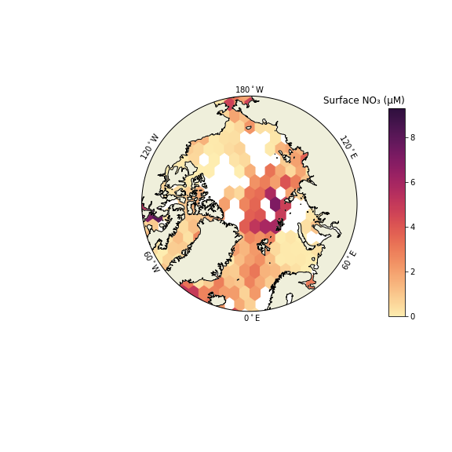

Figure 8: Summer surface nitrate concentration.

A cautionary remark is in order regarding nitrate concentrations as indicators of potential growth. Since the nitrate supply, like phytoplankton growth, is a rate and not a stock, its present-day inventory alone does not yield sufficient information to infer possible limitations in future scenarios. Therefore the summer surplus nitrate observed in the central Arctic Ocean may only be available transiently while the ice cover shrinks, but not in a steady-state situation without summer sea ice.

In other words: If fall blooms are due to upward mixing of new nitrate, they increase new production in the short term. Whether such increases are long-term or if they instead serve to deepen the nitracline depends on the vertical mixing in winter. Similarly, a lengthening ice-free season or a more transparent ice cover lead to a deeper euphotic zone and could enhance growth in subsurface waters, richer in nutrients, but the resupply rate of nitrogen ultimately decides about potential lasting increases in new production.

## Future scenarios

Randelhoff and Guthrie (2016) provided estimates of end-of-century new production, given presently observed turbulence and potential future increases in the freshwater inventory observed in a numerical circulation model (Nummelin et al., 2015). They concluded that a potential increase in new production in the Amundsen Basin (if the system were to turn to nitrate limitation) may fall victim to future increases in vertical stability. Little is known about the future of seasonal and especially summertime stratification in the surface layer (Randelhoff et al., 2017).

Contrarily, Polyakov et al. (2017) posited that an ongoing Atlantification will lead to deeper winter convection in the Eurasian Basin. As Atlantic Water is also the principal source of heat in the Arctic Ocean, it has been implicated in recent sea ice loss (Ivanov et al., 2016; Polyakov et al., 2017), and hence could regionally relieve nutrient and light limitation at the same time (Randelhoff et al., 2018). The recent decreases of sea ice extent in Northern Fram Strait and north of Svalbard (Onarheim et al., 2018) indicate that such a process is already well underway. The analogue may be happening in the Chukchi sea, where the Alaskan Coastal Current brings in both large amounts of heat (Woodgate et al., 2012) and nutrients (Torres-Valdés et al., 2013), but the published literature is less clear on the presence and effects of such a tentative advective borealization of the Chukchi Sea.

## Ice cover and wind-driven turbulence

The published literature is also equivocal on whether or not the decreasing ice cover will enhance turbulent mixing in the upper ocean. While less sea ice may enhance the input of wind energy into the ocean (Dosser and Rainville, 2016; Rainville and Woodgate, 2009), this energy may be dissipated at shallow depths due to the strong stratification (Lincoln et al., 2016). Reanalysis of conductivity-temperature depth and acoustic Doppler current profiler finestructure data has not shown trends in turbulent mixing in recent decades (Chanona et al., 2018; Guthrie et al., 2013).

Broken-up, free-drifting sea ice in summer may enhance wind energy input into the upper ocean compared to ice-covered areas by enhancing surface roughness (Martin et al., 2016) but also decrease vertical turbulent mixing in the surface layer through the associated layer of meltwater (Randelhoff et al., 2017, 2016). Larger freezing rates, caused by increasing proportions of first-year ice, may increase upward mixing, but the potential effects on entrainment of nitrate into the surface layer has to our knowledge not been systematically studied. A major uncertainty in any future prognoses is the scarcity of large-scale surveys of the ice-ocean boundary layer.

## Arctic nitrate fluxes in a global context

Based on a literature review (Table 2), Arctic vertical nitrate fluxes tend to be approximately one order of magnitude lower than in the rest of the world ocean (Fig. 9). Even though study sites in the global ocean may be biased by measurements seeking to explain high biological productivity (most often as the result of strong mixing and upwelling), there is a considerable difference between new production in the Arctic Ocean and the world’s most productive areas.

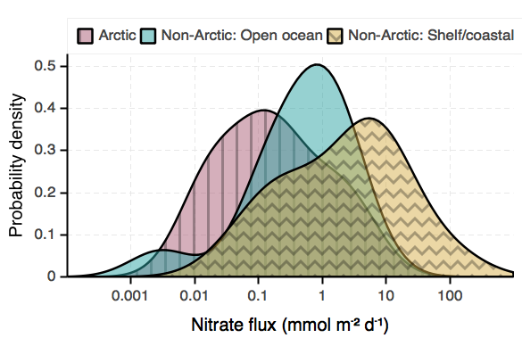

Figure 9: Distributions (kernel density estimates) of observed nitrate fluxes based on Tables 1 and 2. Note that these curves give each observation the same weight, regardless of areal or temporal scope.

# Conclusions

## Avenues for further research

Besides further aggregate scale (seasonal or basin-scale) measurements of the turbulent vertical nitrate flux, two avenues emerge from our conclusions.

1. Advances in turbulence-ecosystem coupling will require dedicated or autonomous sampling and time series. Purely physics-oriented turbulence sampling often does not sufficiently resolve the biologically relevant surface layer.
2. Prediction of upper ocean mixing and ice-ocean interaction depends on sea ice melt and freeze rates, expressed as buoyancy fluxes or in units of meters of freshwater equivalent per unit area. Yet, to our knowledge, this quantity is not routinely investigated as output of coupled ice-ocean circulation models and so no such data product exists that could aid in the extrapolation of Pan-Arctic patterns of the seasonal vertical nitrate flux.

## Upscaling primary production measurements

While currently publicly available datasets may be more comprehensive for new and export production than for nitrate fluxes, they possess some drawbacks concerning evaluating large-scale patterns. As incubations to determine new production are usually point measurements, averaging them is not trivial. Sediment traps, while measuring export fluxes at a single location, integrate the time dimension, and so are more representative, but also require a large logistic effort. Chemical tracer approaches (e.g. Moran et al., 2003) make the data acquisition phase easier, but still require water samples and are hence not easily amenable to autonomous exploration. In sum, current Arctic Ocean exploration does not scale well. Nitrate fluxes, on the other hand, can be estimated purely based on physical sensor data and hence with larger scope both in time and space.

Such turbulence measurements do not necessarily have to be conducted using microstructure profilers - mixing can also be estimated from current shear or density strain fine-structure with more standard instruments, which may work especially well in discerning relative magnitudes but can also be calibrated using regional microstructure estimates (Chanona et al., 2018; Gargett and Garner, 2008; Guthrie et al., 2013; Polzin et al., 2014). Parameterizations of this kind, relying on models of internal wave breaking, are most useful away from boundaries, in scenarios of perennial stratification where year-round background fluxes dominate (Randelhoff and Guthrie, 2016), and less so to characterize near-surface mixing. Other promising avenues are approaches based on turbulence structure functions (Wiles et al., 2006), high-frequency Acoustic Doppler Current Profiler measurements, or microstructure sensors deployed on moorings and gliders (Scheifele et al., 2018).

Turbulence also obeys tight physical constraints imposed by wind, tidal and other energy available for mixing, and by the freshwater (density) fluxes that cause background stratification. Nitrate fluxes may therefore be more easily constrained than plankton photophysiology that is notoriously variable across species and environmental conditions (e.g. Bouman et al., 2018).

## Perspectives

This study has focused on vertical diffusive transport, largely ignoring other transport modes. Upwelling (Carmack and Chapman, 2003; Kämpf and Chapman, 2016), horizontal advection (Torres-Valdés et al., 2013), mesoscale eddy shedding (Watanabe et al., 2014), benthic processes (Renaud et al., 2015), and river biogeochemistry (Frey and McClelland, 2009) all likely affect Arctic Ocean primary production at least regionally. The fact that Pan-Arctic patterns of primary production can seemingly be explained without the need to invoke any of these mechanisms also showcases the stark contrasts between the different Arctic regimes that likely shadow intra-regional nuances.

Mesoscale turbulence can contribute to cross-shelf transport and nutrient supply in the Chukchi sea (Watanabe et al., 2014). Some studies suggest that eddies may also contribute to cross-shelf transport along the West Spitsbergen Current (Hattermann et al., 2016). Crews et al. (2018) found eddies may contribute to ventilation of halocline waters in the European Arctic, meaning they would be apparent in the upward vertical fluxes measured out of the halocline waters instead of contributing directly to mixed-layer nitrate pools. Johnson et al. (2010), working in the Subtropical North Pacific, stressed the importance of event-driven upward nitrate transport not easily captured by vertical diffusivities, and even the possibility of immediate utilisation of nitrate in an otherwise adiabatic isopycnal excursion, for example associated with a passing eddy. Attention is required summing these contributions, however, as there is a certain danger of double counting nitrate fluxes in eddies (Martin and Pondaven, 2003; Martin and Richards, 2001).

Advection with ocean currents manifests itself largely as transport with the Pacific and Atlantic currents that e.g. Torres-Valdés et al. (2013) have discussed. For the most part, these currents are subducted under local (Arctic) water masses and can hence be accounted for as part of the vertical fluxes downstream. Randelhoff et al. (2016) have argued that as these currents come from further south where primary production starts earlier and terminates later, the surface waters they carry are as nutrient-depleted as the Arctic surface waters. This argument has, however, never been tested quantitatively. Similarly, upwelling along coasts, shelf breaks, in eddies, and at marine-terminating glaciers may contribute regionally to ocean productivity (Carmack and Chapman, 2003; Kämpf and Chapman, 2016; Meire et al., 2017). Arguments as to how exactly upwelling is caused and how it impacts nutrient fluxes have largely remained qualitative (Randelhoff and Sundfjord, 2018; but see Spall et al., 2014 for a careful modelling exercise).

Lastly, turbulent mixing is much more than only the vertical nitrate flux. It affects predator-prey interactions (Kiørboe, 2008), nutrient uptake rates at the cell level (Karp-Boss et al., 1996), light exposure of individual cells (Sverdrup, 1953), etc. In fact, mixing and variability is a resource in itself that can be exploited by different plankton life strategies (Margalef, 1978). These concepts may turn out to be important in particular when interpreting regional specifics such as biological hotspots. As methods advance and measurements accumulate, we expect that more efforts can be dedicated to studying regional phenomena in a Pan-Arctic unified manner.

# Conflict of Interest

The authors declare that the research was conducted in the absence of any commercial or financial relationships that could be construed as a potential conflict of interest.

# Author Contributions

AR designed the study, made all visualizations, and wrote the first draft of the manuscript. AR, JH, and MKS conducted field sampling and data analysis of the Young Sound data. MBA and MJ sampled and analyzed the Laptev Sea data. MB lead the acquisition of the Baffin Bay data. JET contributed Canadian Archipelago nutrient data. All authors commented on the manuscript.

# Funding

Data acquisition of BGC-Argo Floats in Baffin Bay was funded through the NAOS project. Work in Young Sound was supported by the DANCEA project “De-icing Arctic coasts” and the Greenland Ecosystem Monitoring Programme. AR was supported by the Sentinel North program of Université Laval, partly funded by the Canada First Research Excellence Fund, and Carbon Bridge, a Polar Programme (project 226415) funded by the Norwegian Research Council. JMH was supported by the European Commission H2020 programme under the Marie Skłodowska-Curie Actions (GrIS-Melt: grant no. 752325). MBA was supported by the National Science Foundation (PLR-1203146 AM003) and the National Oceanic and Atmospheric Administration (NA15OAR4310156). MJ was supported by the German Ministry of Science and Education (BMBF) under grants 03G0833, 03F0776, and 03F0804A.

# Acknowledgments

The present paper started taking shape around the 4th “Symposium on Pan-Arctic Integration”, held in Motovun, Croatia, 2017, and we thank all participants for inspiring discussions. We also thank two anonymous reviewers for their help.

We thank Andrey Novikhin (AARI) for preparing the nutrient measurements from the Laptev Sea shelf, Xiaogang Xing for quality-controlling and calibrating the Baffin Bay BGC Argo data, and Jørgen Bendtsen and Torben Vang for providing Young Sound bathymetry data. We are further grateful to Shigeto Nishino for clarifying discussions about his work in the Chukchi Sea.

Data exploration and visualization relied heavily on the [Holoviews library](http://holoviews.org) (Stevens et al., 2015).

# Supplementary Material

The supplemental material (Randelhoff, 2020), accessible at [Github](https://github.com/poplarShift/arctic-nitrate-fluxes) and [Zenodo](https://zenodo.org/badge/latestdoi/203251426), contains:

- The python code necessary to reproduce all analyses and figures, licensed under GNU GPL3.
- The data, as plotted in all figures, in machine-readable formats.
- An interactive version of this article where figures can be zoomed, panned, and selectively highlighted (as appropriate) leveraging the [Bokeh library](http://bokeh.pydata.org) (Bokeh Development Team, 2018).

# Data Availability Statement

All data that were published for the first time in this study are included with the above repository. The rest are included to the extent possible.

# Appendix

## The marine nitrogen cycle

Discussions of ocean surface nitrogen budgets center around the marine nitrogen cycle. Fig. 5 shows a simplified version adapted to Arctic conditions. The main component is the cycling between inorganic nitrate and particulate organic nitrogen (PON). Upward transport of NO₃⁻ compensates nitrate uptake by algae into PON (Dugdale and Goering, 1967) and subsequent sinking of this organic matter. The loop is closed by remineralization into nitrate at depth. When nitrogen is scarce in the surface layer, there is also intense recycling of nitrogen that has already been assimilated into organic matter, which is called regenerated production.

Additional complexity arises from a number of sources, sinks, and recycling processes not accounted for in this simplistic view. One of the conclusions of the present study is that we do not need to invoke those processes to understand Arctic surface layer budgets on a Pan-Arctic scale. Riverine inputs of nitrate are thought to be sufficiently small to be neglected at larger-than-regional scales (see e.g. Tank et al., 2012). Some of the produced PON is also harvested e.g. by higher trophic levels or fisheries (e.g. Valiela, 2015), although the latter process is likely only regionally important, e.g. in the Barents Sea. Other factors may be important depending on the regional scope. Advection, upwelling, and mesoscale mixing have already been discussed in the main text. Nitrification, denitrification, and nitrogen fixation are in general not well constrained in the Arctic Ocean (Blais et al., 2012; Sipler et al., 2017; Tremblay et al., 2008). Randelhoff et al. (2015), for instance, argued that winter vertical turbulent nitrate fluxes in areas with deep mixing are likely much larger than nitrification, but did so based on sparse data. A complete assessment of all these factors is beyond the scope of this paper.

## The vertical layering of Arctic Ocean nitrate

Fluxes are easiest to measure across strong gradients. A given vertical profile of nitrate concentrations in the Arctic Ocean can schematically be vertically divided by two nitraclines (Fig. 5A): First, a seasonal one, which marks the transition from surface waters, modulated by seasonal freshwater from ice melt or terrestrial runoff and algal growth, to the remnant winter mixed layer. Second, and mostly present in the deep basins of the Arctic Ocean, one that we dub “perennial” as it is not eroded and re-established on an annual basis.

The seasonal nitracline may be completely mixed during winter (Fig. 5B), rendering fluxes hard to estimate using the “diffusivity times gradient” formula. Across the perennial nitracline, fluxes can be estimated year-round stipulating the seasonal variations in nitracline dissipation are minor, a method exploited by Randelhoff and Guthrie (2016) to estimate Pan-Arctic patterns of upward nitrate supply in the deep basin. In practice, the two nitraclines are often not clearly delineated. The distinctive characteristics of the two nitraclines are most easily seen in the Eurasian Basin, where deep winter mixed layers are clearly separated from underlying Atlantic Waters. In the Canadian Basin, strong stratification prevents winter mixing from penetrating deep into the nitracline (Peralta-Ferriz and Woodgate, 2015), leading to relatively small seasonal excursions in surface nutrient concentrations and a less distinct winter remnant mixed layer (Fig. 5C).

Consequently, we classified the seasonality of all vertical nitrate flux estimates discussed in this paper in terms of whether the water column mixes deeply (“overturns”) in winter or not (in which case stratification is dubbed “perennial”). We used the published literature for each location as well as the data set corresponding to the flux estimate, if available. Importantly, our classification is generally well-founded but occasionally ad-hoc and tentative due to sparse data. An illustrative example are three summertime flux estimates north of the Barents sea polar front (Sundfjord et al., 2007; Wiedmann et al., 2017). For instance, Loeng (1991) indicates a weak but persistent salinity stratification in the Arctic water mass throughout winter, but the few vertical nitrate profiles available in our compiled data set indicate a seasonal cycle of surface nitrate in line with what is seen south of the Polar Front. These three fluxes were hence classified as being in a location where the water column overturns in winter because we focused on the vertical structure of nitrate profiles. Either way, because all three fluxes were based on a small sample size, not too much weight was given to them in the overall analysis.

## Measuring vertical nitrate fluxes

Barring regionally important processes such as upwelling and eddy pumping (Carmack and Chapman, 2003; Kämpf and Chapman, 2016; Randelhoff and Sundfjord, 2018), the most prevalent form of the upward transport of nitrate in the ocean is turbulent diffusion (Lewis et al., 1986). Such diffusion mixes the spent surface waters with deeper, more nutrient-rich waters, thereby replenishing their nitrate reservoir. A vertical turbulent nitrate flux is, by definition, the product of a so-called “diapycnal eddy diffusivity” with the vertical gradient of nitrate. This is completely analogous to any other tracer such as temperature or salinity. The interested reader is referred to the vast literature on turbulent flows.

To estimate both those quantities, one has to measure the turbulence and a vertical profile of nitrate concentrations at the same time and location. Determining nitrate concentrations is comparatively uncomplicated because only the non-turbulent background is needed; one can use either bottle samples or, preferably, optical nitrate sensors to achieve a better vertical resolution (Alkire et al., 2010; Randelhoff et al., 2016). Both of these options are easily integrated into standard sampling with a CTD rosette. While care should be taken to calibrate the absolute concentrations of optical sensors against water samples, such biases are usually depth-independent and hence do not matter for the calculation of the gradients (see Appendix of Randelhoff et al., 2016). Measuring turbulence is more challenging because it requires either measurements with sophisticated instruments, requiring dedicated ship time and personnel, or parameterizations that add layers of uncertainty (e.g. Garrett and Munk, 1975; Guthrie et al., 2013).

### Measuring turbulence

The most direct way of determining a nitrate flux is measuring the so-called “dissipation of turbulent kinetic energy” ($\epsilon$) traditionally using free-falling microstructure profilers (Lueck et al., 2002). $\epsilon$ can also be estimated from finescale current shear (i.e. current profiles) or strain visible in CTD profiles (Guthrie et al., 2013). Once $\epsilon$ is determined, its accuracy usually cited as being within a factor of two (Moum et al., 1995), the vertical turbulent diffusivity can be calculated, following Osborn (1980), as

$$K_\rho = \Gamma\frac{\epsilon}{N^2}\qquad(1)$$

where $N^2$ is the Brunt-Väisälä buoyancy frequency and $\Gamma\approx 0.2$ is the mixing coefficient that reflects how much of $\epsilon$ is available for diabatic mixing. Eq. 1 has a number of known issues, a major one being that $\Gamma$ is not constant. A variety of different parameterizations have been proposed (e.g. Shih et al., 2005; Bouffard and Boegman, 2013), with no clear alternative emerging. Eq. 1 is hence the de facto standard (Gregg et al., 2018), and in fact all turbulence-based estimates of the vertical nitrate flux compiled for this paper are based on it. Most often, $\Gamma=0.2$ is used, but e.g. Sundfjord et al. (2007) used $\Gamma=0.12$ following recommendations in the literature consistent with their dataset (see references therein).

### Using the inorganic nitrate drawdown as an indicator of nitrate flux

Another method to determine vertical nitrate fluxes, less direct, uses a set of nitrate profiles through fall and winter (Randelhoff et al., 2015). It has been employed to calculate two of the fluxes presented in this study. Vertically integrating the successive differences between them, one essentially reverses the calculation of net community production by the nitrate drawdown between winter and summer (Codispoti et al., 2013). Randelhoff et al. (2015) provided a brief overview over potentially interfering processes such as nitrogen fixation (Blais et al., 2012) and concluded they were likely not significantly disturbing the annual budgets, but it has to be acknowledged that data is sparse. While this method may be robust in the pelagic, one can doubt its effectiveness in waters where nitrogen cycling is heavily affected by other processes, such as benthic processes in shallow waters, or coastal effects.

## New estimates of nitrate fluxes and new production in Young Sound, NE Greenland

### Methods

Sampling in the Young Sound/Tyrolerfjord system was conducted during three weeks in August 2015 from the Daneborg research station as part of the Danish MarineBasis program in Zackenberg (Fig. 10A).

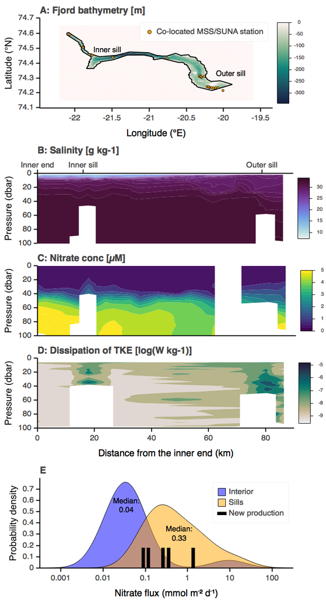

Figure 10: Young Sound data. (A) Bathymetry and coast data courtesy T. Vang and J. Bendtsen (Rysgaard et al. (2003); not included in the supplemental material). Transect starting in the inner end of the fjord, going over two sills and out into the Greenland Sea, demonstrating (B) low salinity due to ice sheet runoff, (C) nitrate depletion in the upper 30-40 meters, and (D) a quiescent fjord interior with vigorous mixing over the two sills. (E) Upward nitrate fluxes observed in Young Sound (shaded areas represent kernel density estimates) and observed values of new production, integrated over 0-20 meters (black bars). Note that new production estimates are based on only two measurement depths; see methods.

Water column nutrient samples were taken at 5 stations using a manually operated Niskin bottle from depths of 1, 5, 10, 20, 30, 40, 50, and 100 m. They were filtered with Whatman GF/F filters before being stored in previously acid-washed 30 mL high-density polyethylene (HDPE) plastic bottles and frozen until analysis (-18 °C). Nitrite (NO2) and nitrate (NO₃⁻) concentrations in each sample were measured on a Smartchem200 (AMS Alliance) autoanalyzer.

An MSS-90L (Sea and Sun Technology, Germany) free-falling microstructure profiler was deployed at a total of 37 stations, many of them repeat stations, to measure vertical profiles of the dissipation of turbulent kinetic energy. At the same stations, we deployed a SUNA (Satlantic) nitrate spectrophotometer to collect co-located vertical profiles of nitrate concentration. SUNA profiles were post-processed following (Randelhoff et al., 2016) and calibrated using a constant bias determined from comparison with the nutrient water samples.

New and regenerated production were investigated at a subset of five stations. They were measured in two parallel incubations, labelled with ca. 10% ambient concentration of ¹⁵NO₃⁻ and ¹⁵NH₄⁺ respectively. Water samples were incubated in triplicate 500 ml polycarbonate bottles in situ. Additionally ca. 10% ambient concentration of ¹³C-bicarbonate was added to both sets of incubations to follow the incorporation of inorganic carbon into biomass. Samples were taken for NO₂⁻+NO₃⁻ , ¹⁵NO₃⁻ and ¹⁵NH₄⁺ before and after addition of tracers by filtering through a syringe filter (Whatman GF/C) into 10 ml polystyrene vials which were frozen (-18 °C) until analysis. After the incubation the particulate matter from each incubation vessel was filtered onto pre-combusted GF/F filters and later the ¹⁵N and ¹³C content of the particles on the filters was determined by mass spectrometry. Before filtration a third set of samples for NO₂⁻+NO₃⁻, ¹⁵NO₃⁻ and ¹⁵NH₄⁺ were taken. NO₂⁻+NO₃⁻ was determined photometrically following Schnetger and Lehners (2014). ¹⁵NH₄⁺ was determined based on Risgaard-Petersen et al. (1995). ¹⁵NO₃⁻ was determined as in Kalvelage et al. (2011). New and regenerated production were calculated as the ratio of nitrate or ammonium to total N-uptake in each incubation respectively multiplied by the total C-uptake in each incubation.

In total, we collected 43 profiles of co-located SBE25+SUNA profiles, 103 MSS casts, 40 nutrient bottle samples and 20x3 triplicates of new and regenerated production incubations.

### Results

A freshwater layer was present throughout the fjord, but most prominent in the innermost parts (Fig. 10B-D). Nitrate was depleted throughout the upper 40 m, below which concentrations steeply rose to about 4 µM. The fjord was remarkably quiescient in terms of turbulent dissipation rates, but mixing was significantly elevated over the sills. Vertical nitrate fluxes, computed for each station of co-located MSS and SUNA measurements, ranged from 0.012 to 13.26 mmol N m⁻² d⁻¹, with some of the values in the fjord interior being the lowest observed across this entire study. Median upward fluxes were 0.036 and 0.33 mmol N m⁻² d⁻¹ in the fjord interior and over the sills, respectively. Incubations, although only available at two depths (5 and 20 m), indicated new production rates on the order of 0.1 to 1 mmol N m⁻² d⁻¹ (Fig. 10E).

## Nitrate flux estimate in the Laptev Sea

### Data description

Microstructure and nutrient measurements from the Laptev Sea were collected under the framework of the German-Russian “Laptev Sea System”-partnership in winter 2008 and the summers of 2011, 2014, and 2018 (Fig. 11B). The 2008 profile was averaged from measurements collected during the helicopter-supported “Transdrift 13” winter expedition (6 April to 10 May 2008) to the southeastern Laptev shelf. The summer nitrate profile was averaged from profiles collected during the “Transdrift 19” expedition on board the RV Jakov Smirnitsky in September 2011 (Bauch et al., 2018).

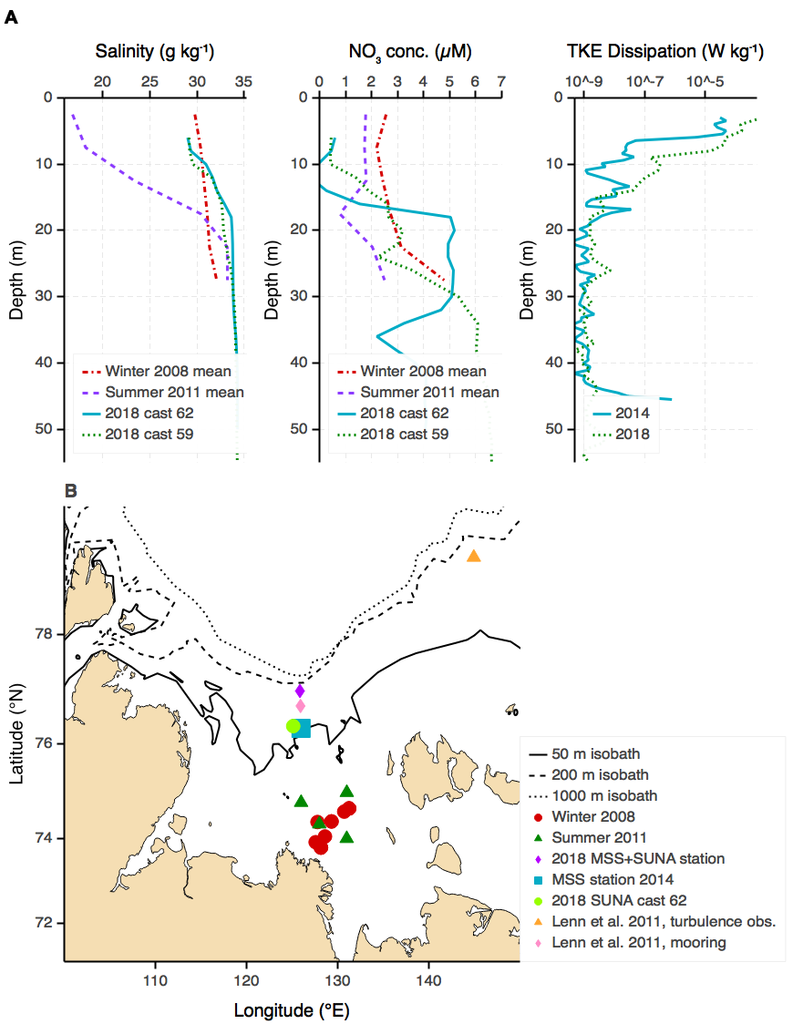

Figure 11: Laptev Sea data. (A) Vertical profiles of salinity, nitrate concentration and dissipation of turbulent kinetic energy ($\epsilon$) in the Laptev Sea. (B) Measurement locations in the Laptev Sea.

In 2014 microstructure turbulence profiles were collected on 19 September 2014 during the Transdrift 22-expedition aboard the RV Viktor Buinitsky (see Janout et al., to be submitted to this issue). The dissipation rates of turbulent kinetic energy ($\epsilon$) were derived from shear variance measured with a freely falling MSS-90L microstructure profiler manufactured by Sea and Sun Technology (SST, Germany). Vertical profiles of epsilon were calculated from the isotropic formula and spectral analysis of 1-s segments and subsequently averaged into 1-m bins. Turbulent vertical fluxes are based on a diapycnal eddy diffusivity with a constant mixing efficiency taken to be 0.2 (Osborn, 1980). For statistical robustness, the 2014 MSS profile shown in this paper was averaged from a series of five casts.

In 2018 a joint German-US-Russian expedition to the Eurasian Arctic was carried out aboard the RV Akademik Tryoshnikov from 18 August to 30 September 2018. The expedition combined the German-Russian CATS (Changing Arctic Transpolar System) and the US-Russian NABOS (Nansen Amundsen Basin Observing System) programs. The dissipation profile was again generated with a MSS-90L, while the nitrate profile was recorded with a Deep SUNA V2 nitrate profiler (Seabird Scientific) attached to the shipboard CTD/rosette. These data files were then processed using a program (ISUSDataProcessor) developed by Ken Johnson (MBARI) that corrects the spectral data for temperature effects on the bromide absorption and applies a linear baseline correction to account for absorption by colored dissolved organic matter (Sakamoto et al., 2009). SUNA nitrate concentrations were then compared with nitrate concentrations measured from discrete seawater samples collected at various depths above 20 and below 300 m depth where concentrations were sufficiently constant with depth. The full description of the methods is distributed with the data (Alkire, 2019).

### Nitrate fluxes

Two representative profiles were selected to compute nitrate fluxes (Fig. 11A): Cast 59 and a co-located MSS profile, both sampled in 2018, and the 2014 MSS profiles and cast 62, also co-located but from separate years. For both profiles, we visually determined the nitracline, averaged ε over that interval, and computed the average nitrate and density gradients by a linear regression. The resulting nitrate fluxes were 0.014 and 0.017 mmol N m⁻² d⁻¹, and hence we entered the average value of 0.015 mmol N m⁻² d⁻¹ for the Laptev Sea into the nitrate fluxes compilation.

Even though we have a winter and a summer vertical profile of nitrate concentrations, we cannot calculate a winter flux using the integrated drawdown (Codispoti et al., 2013; Randelhoff et al., 2015) because comparison of the winter and summer profiles does not indicate any reliable vertical structure in the drawdown. This may indicate that winter fluxes might be too small to make a noticeable difference between the summer and winter profiles. More importantly, in such a shallow shelf sea, other factors (such as benthic nitrogen cycling or riverine freshwater) may also play a role as detailed above.

## Nitrate flux estimate in Baffin Bay

Three biogeochemical Argo floats, part of the NAOS project, overwintered in Baffin Bay from July 2017 to July 2018, described in detail by Randelhoff et al. (2020, in prep.).

Nitrate concentration was observed by the Satlantic Submersible Ultraviolet Nitrate Analyzer (SUNA). Each sensor’s offset, taken to be constant and depth-independent (Randelhoff et al., 2016), was corrected based on nitrate concentration profiles sampled during deployment of the floats. Mixed layer depth was defined as the shallowest depth where density rose more than 0.1 kg m⁻³ above the surface density.

Integrating the nitrate deficit $\Delta [NO₃⁻]\equiv [NO₃⁻](60 m) - [NO₃⁻](z)$ over the upper 60 meters for each station shows that over the course of four months (from November to March), a deficit of 200 mmol N m⁻² was replenished, approximately equivalent to an upward nitrate flux of 1.66 mmol N m⁻² d⁻¹ (Fig. 12). Although each float was drifting during the course of the winter, which may have introduced advective changes, the floats were well dispersed across Baffin Bay and should give a representative picture of winter mixed layer evolution. Details are deferred to the aforementioned manuscript (Randelhoff et al., in prep.). The usual caveats about neglecting mixed-layer regeneration and consumption of nutrients apply, and so this calculation makes the same kind of assumptions as have been detailed by Randelhoff et al. (2015).

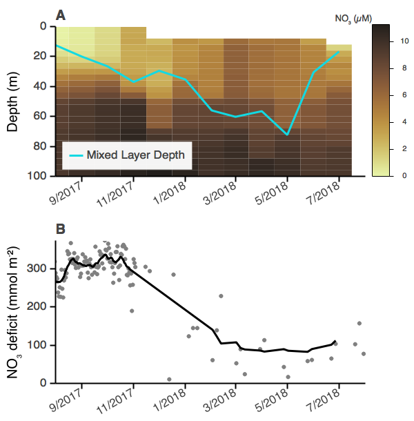

Figure 12: Seasonal cycle of nitrate concentrations in Baffin Bay alongside mixed layer depth (A) and the 0-60 m vertically integrated nitrate deficit $\Delta [NO₃⁻]=[NO₃⁻](60 m) - [NO₃⁻](z)$ (B).

# Tables

Table 1: Nitrate fluxes observed in the Arctic Ocean. * Turbulent vertical nitrate flux given in mmol N m⁻² d⁻¹. ** Under ice cover. *** Open water. AABC: Anticyclonic Arctic Boundary Current. See Supplementary Material for complete data set.

| Region | Season | NO₃⁻ flux* | Reference | Sample size | Turbulence meas. | NO₃⁻ meas. |
| --- | --- | --- | --- | --- | --- | --- |
| Amundsen Basin | Winter | 0.05 | Randelhoff and Guthrie (2016) | Large | Microstruct. | Optic |
| Baffin Bay | Winter | 1.7 | this study | Large | N/A | Optic |
| Barents Sea | Summer | 0.1 | Sundfjord et al. (2007) | Small | Microstruct. | Bottle |
| Barents Sea | Summer | 0.1 | Wiedmann et al. (2017) | Small | Microstruct. | Optic |
| Barents Sea | Summer | 2.0 | Sundfjord et al. (2007) | Small | Microstruct. | Bottle |
| Barents Sea | Summer | 5.0 | Wiedmann et al. (2017) | Small | Microstruct. | Optic |
| Barents Sea, AABC | Winter | 2.5 | Randelhoff et al. (2015) | Large | N/A | Optic |
| Beaufort Sea | Winter | 0.12 | Bourgault et al. (2011) | Large | Microstruct. | Optic |
| Canada Basin | Winter | 0.01 | Randelhoff and Guthrie (2016) | Large | Finestruct. | Optic |
| Chukchi Sea | Summer | 0.02 | this study, Nishino et al. (2015) | Small | Microstruct. | Bottle |
| Chukchi Sea | Summer | 0.19 | Nishino et al. (2018) | Large | Microstruct. | Bottle |
| Laptev Shelf (outer) | Summer | 0.015 | this study | Small | Microstruct. | Bottle & Optic |
| Makarov Basin | Winter | 0.015 | Randelhoff and Guthrie (2016) | Large | Finestruct. | Optic |
| N Svalbard/Fram Strait | Summer | 0.3** | Randelhoff et al. (2016) | Large | Microstruct. | Optic |
| N Svalbard/Fram Strait | Summer | 0.7*** | Randelhoff et al. (2016) | Large | Microstruct. | Optic |
| Nansen Basin/Yermak Plateau | Winter | 0.2 | Randelhoff and Guthrie (2016) | Large | Microstruct. | Optic |
| Young Sound (Interior) | Summer | 0.035 | this study | Large | Microstruct. | Optic |
| Young Sound (Sills) | Summer | 0.33 | this study | Large | Microstruct. | Optic |

Table 2: Nitrate fluxes in the global ocean, excluding the Arctic. * Turbulent vertical nitrate flux given in mmol N m⁻² d⁻¹.

| Reference | NO₃⁻ flux* | Region |
| --- | --- | --- |
| Lewis et al. (1986) | 0.14 | Subtropical North Atlantic |
| Jenkins (1988) | 1.6 | Subtropical North Atlantic |
| Hamilton et al. (1989) re-analyzing Lewis et al. (1986) | 0.85 | Subtropical North Atlantic |
| Carr et al. (1995) | 1.9 | Equatorial Pacific (5 °N - 5 °S) |
| Carr et al. (1995) | 4.3 | Equatorial Pacific (1 °N - 1 °S) |
| Horne et al. (1996) | 0.047 | North Atlantic, Georges Bank |
| Horne et al. (1996) | 0.18 | North Atlantic, Georges Bank |
| Planas et al. (1999) | 0.38 | Central Atlantic |
| Law et al. (2001) | 1.8 | Subarctic North Atlantic |
| Sharples et al. (2001) | 12.0 | New Zealand Shelf |
| Law (2003) | 0.17 | Antarctic Circumpolar Current |
| Hales (2005) | 9.0 | Oregon Shelf Upwelling System |
| Sharples et al. (2007) | 1.3 | Celtic Sea shelf edge (neap tide) |
| Sharples et al. (2007) | 9.0 | Celtic Sea shelf edge (spring tide) |
| Hales et al. (2009) | 0.9 | New England shelf break front (seaward side) |
| Hales et al. (2009) | 5.2 | New England shelf break front (shoreward side) |
| Rippeth et al. (2009) | 1.5 | Irish Sea |
| Martin et al. (2010) | 0.09 | North Atlantic, Porcupine Abyssal Plain |
| Schafstall et al. (2010) | 1.0 | Mauritanian Upwelling (offshore) |
| Schafstall et al. (2010) | 3.7 | Mauritanian Upwelling (shelf) |
| Schafstall et al. (2010) | 10.0 | Mauritanian Upwelling (slope) |
| Shiozaki et al. (2011) | 0.25 | North Pacific, East China Sea shelf |
| Kaneko et al. (2013) | 0.003 | North Pacific, Kuroshio (south of front) |
| Kaneko et al. (2013) | 0.34 | North Pacific, Kuroshio (north of front) |
| Cyr et al. (2015) | 0.21 | St. Lawrence Gulf, Canada |
| Cyr et al. (2015) | 95.0 | St. Lawrence Gulf, Canada (shallow sill) |

# References

Aagaard, K., and Carmack, E. C. (1989). The role of sea ice and other fresh water in the Arctic circulation. *Journal of Geophysical Research: Oceans* 94, 14485–14498. doi:10.1029/JC094iC10p14485.

Agawin, N. S. R., Duarte, C. M., and Agustí, S. (2000). Nutrient and temperature control of the contribution of picoplankton to phytoplankton biomass and production. *Limnology and Oceanography* 45, 591–600. doi:10.4319/lo.2000.45.3.0591.

Alkire, M. (2019). Ocean conductivity, temperature, density (CTD), oxygen, and nitrate profiles, Eurasian and Makarov basins, Arctic Ocean, 2013-2018. doi:10.18739/A24X54G9W.

Alkire, M. B., Falkner, K. K., Morison, J., Collier, R. W., Guay, C. K., Desiderio, R. A., et al. (2010). Sensor-based profiles of the NO parameter in the central Arctic and southern Canada Basin New insights regarding the cold halocline. *Deep-Sea Research Part I-Oceanographic Research Papers* 57, 1432–1443. doi:10.1016/j.dsr.2010.07.011.

Allen, T. F. H., and Hoekstra, T. W. (2015). *Toward a unified ecology*. Second edition. New York: Columbia University Press.

Ambühl, H. (1959). Die Bedeutung der Strömung als ökologischer Faktor. *Schweizerische Zeitschrift für Hydrologie* 21, 133. doi:10.1007/BF02505455.

Ardyna, M., Babin, M., Gosselin, M., Devred, E., Rainville, L., and Tremblay, J.-É. (2014). Recent Arctic Ocean sea ice loss triggers novel fall phytoplankton blooms. *Geophysical Research Letters* 41, 6207–6212. doi:10.1002/2014gl061047.

Arrigo, K. R., Mills, M. M., Dijken, G. L. van, Lowry, K. E., Pickart, R. S., and Schlitzer, R. (2017). Late Spring Nitrate Distributions Beneath the Ice-Covered Northeastern Chukchi Shelf. *Journal of Geophysical Research: Biogeosciences* 122, 2409–2417. doi:10.1002/2017JG003881.

Bauch, D., Cherniavskaia, E., Novikhin, A., and Kassens, H. (2018). Physical oceanography, nutrients, and $\Delta{}^{18}$O measured on water bottle samples in the Laptev Sea, supplement to: Bauch, D; Cherniavskaia, Ekaterina (2018): Water Mass Classification on a Highly Variable Arctic Shelf Region: Origin of Laptev Sea Water Masses and Implications for the Nutrient Budget. Journal of Geophysical Research: Oceans. doi:10.1594/PANGAEA.885448.

Biogeochemical-Argo Planning Group (2016). The scientific rationale, design and implementation plan for a Biogeochemical-Argo float array. Ifremer doi:10.13155/46601.

Blais, M., Tremblay, J.-É., Jungblut, A. D., Gagnon, J., Martin, J., Thaler, M., et al. (2012). Nitrogen fixation and identification of potential diazotrophs in the Canadian Arctic. *Global Biogeochemical Cycles* 26. doi:10.1029/2011gb004096.

Bluhm, B. A., Kosobokova, K. N., and Carmack, E. C. (2015). A tale of two basins: An integrated physical and biological perspective of the deep Arctic Ocean. *Progress in Oceanography* 139, 89–121. doi:10.1016/j.pocean.2015.07.011.

Bokeh Development Team (2018). *Bokeh: Python library for interactive visualization*. Available at: https://bokeh.pydata.org/en/latest/.

Bouffard, D., and Boegman, L. (2013). A diapycnal diffusivity model for stratified environmental flows. *Dynamics of Atmospheres and Oceans* 61-62, 14–34. doi:10.1016/j.dynatmoce.2013.02.002.

Bouman, H. A., Platt, T., Doblin, M., Figueiras, F. G., Gudmundsson, K., Gudfinnsson, H. G., et al. (2018). Photosynthesis-Irradiance parameters of marine phytoplankton: Synthesis of a global data set. *Earth System Science Data* 10, 251–266. doi:https://doi.org/10.5194/essd-10-251-2018.

Bourgault, D., Hamel, C., Cyr, F., Tremblay, J.-É., Galbraith, P. S., Dumont, D., et al. (2011). Turbulent nitrate fluxes in the Amundsen Gulf during ice-covered conditions. *Geophysical Research Letters* 38. doi:10.1029/2011GL047936.

Brzezinski, M. A. (1985). The Si:C:N ratio of marine diatoms: Interspecific variability and the effect of some environmental variables. *Journal of Phycology* 21, 347–357.

Cai, P., Rutgers van der Loeff, M., Stimac, I., Nöthig, E.-M., Lepore, K., and Moran, S. B. (2010). Low export flux of particulate organic carbon in the central Arctic Ocean as revealed by 234Th:238U disequilibrium. *Journal of Geophysical Research: Oceans* 115, n/a–n/a. doi:10.1029/2009JC005595.

Carmack, E., Barber, D., Christensen, J., Macdonald, R., Rudels, B., and Sakshaug, E. (2006). Climate variability and physical forcing of the food webs and the carbon budget on panarctic shelves. *Progress in Oceanography* 71, 145–181. doi:10.1016/j.pocean.2006.10.005.

Carmack, E. C. (2007). The alpha/beta ocean distinction: A perspective on freshwater fluxes, convection, nutrients and productivity in high-latitude seas. *Deep Sea Research Part II: Topical Studies in Oceanography* 54, 2578–2598. doi:10.1016/j.dsr2.2007.08.018.

Carmack, E., and Chapman, D. C. (2003). Wind-driven shelf/basin exchange on an Arctic shelf: The joint roles of ice cover extent and shelf-break bathymetry. *Geophys. Res. Lett.* 30. doi:10.1029/2003gl017526.

Carmack, E., and Wassmann, P. (2006). Food webs and physical - biological coupling on pan-Arctic shelves: Unifying concepts and comprehensive perspectives. *Progress in Oceanography* 71, 446–477. doi:10.1016/j.pocean.2006.10.004.

Carr, M.-E., Lewis, M. R., Kelley, D., and Jones, B. (1995). A physical estimate of new production in the equatorial Pacific along 150W. *Limnology and Oceanography* 40, 138–147. doi:10.4319/lo.1995.40.1.0138.

Chanona, M., Waterman, S., and Gratton, Y. (2018). Variability of Internal Wave-Driven Mixing and Stratification in Canadian Arctic Shelf and Shelf-Slope Waters. *Journal of Geophysical Research: Oceans* 123, 9178–9195. doi:10.1029/2018JC014342.

Chisholm, S. W. (1992). “Phytoplankton Size,” in *Primary Productivity and Biogeochemical Cycles in the Sea* Environmental Science Research., eds. P. G. Falkowski, A. D. Woodhead, and K. Vivirito (Boston, MA: Springer US), 213–237. doi:10.1007/978-1-4899-0762-2_12.

Cochlan, W. P., and Harrison, P. J. (1991). Kinetics of nitrogen (nitrate, ammonium and urea) uptake by the picoflagellate Micromonas pusilla (Prasinophyceae). *Journal of Experimental Marine Biology and Ecology* 153, 129–141. doi:10.1016/0022-0981(91)90220-Q.

Codispoti, L. A., Kelly, V., Thessen, A., Matrai, P., Suttles, S., Hill, V., et al. (2013). Synthesis of primary production in the Arctic Ocean: III. Nitrate and phosphate based estimates of net community production. *Progress in Oceanography* 110, 126–150. doi:10.1016/j.pocean.2012.11.006.

Cole, S. T., Toole, J. M., Rainville, L., and Lee, C. M. (2018). Internal waves in the Arctic: Influence of ice concentration, ice roughness, and surface layer stratification. *Journal of Geophysical Research: Oceans*. doi:10.1029/2018JC014096.

Comiso, J. C. (2012). Large decadal decline of the Arctic multiyear ice cover. *Journal of Climate* 25, 1176–1193. doi:10.1175/JCLI-D-11-00113.1.

Crews, L., Sundfjord, A., Albretsen, J., and Hattermann, T. (2018). Mesoscale Eddy Activity and Transport in the Atlantic Water Inflow Region North of Svalbard. *Journal of Geophysical Research: Oceans* 123, 201–215. doi:10.1002/2017JC013198.

Cyr, F., Bourgault, D., Galbraith, P. S., and Gosselin, M. (2015). Turbulent nitrate fluxes in the Lower St. Lawrence Estuary (Canada). *J. Geophys. Res. Oceans*, n/a–n/a. doi:10.1002/2014jc010272.

Dosser, H. V., and Rainville, L. (2016). Dynamics of the Changing Near-Inertial Internal Wave Field in the Arctic Ocean. *Journal of Physical Oceanography* 46, 395–415. doi:10.1175/jpo-d-15-0056.1.

Dugdale, R. C., and Goering, J. J. (1967). Uptake of new and regenerated forms of nitrogen in primary productivity. *Limnology and Oceanography* 12, 196–206. doi:10.4319/lo.1967.12.2.0196.

Eppley, R. W., Rogers, J. N., and McCarthy, J. J. (1969). Half-Saturation Constants for Uptake of Nitrate and Ammonium by Marine Phytoplankton1. *Limnology and Oceanography* 14, 912–920. doi:10.4319/lo.1969.14.6.0912.

Fer, I., and Drinkwater, K. (2014). Mixing in the Barents Sea Polar Front near Hopen in spring. *Journal of Marine Systems* 130, 206–218. doi:10.1016/j.jmarsys.2012.01.005.

Frey, K. E., and McClelland, J. W. (2009). Impacts of permafrost degradation on arctic river biogeochemistry. *Hydrological Processes* 23, 169–182. doi:10.1002/hyp.7196.

Frigstad, H., Andersen, T., Bellerby, R. G. J., Silyakova, A., and Hessen, D. O. (2014). Variation in the seston C:N ratio of the Arctic Ocean and pan-Arctic shelves. *Journal of Marine Systems* 129, 214–223. doi:10.1016/j.jmarsys.2013.06.004.

Gargett, A., and Garner, T. (2008). Determining Thorpe Scales from Ship-Lowered CTD Density Profiles. *Journal of Atmospheric and Oceanic Technology* 25, 1657–1670. doi:10.1175/2008jtecho541.1.

Garrett, C., and Munk, W. (1975). Space-time scales of internal waves: A progress report. *Journal of Geophysical Research* 80, 291–297. doi:10.1029/JC080i003p00291.

Gregg, M. C., D’Asaro, E. A., Riley, J. J., and Kunze, E. (2018). Mixing Efficiency in the Ocean. *Annual Review of Marine Science* 10, 443–473. doi:10.1146/annurev-marine-121916-063643.

Guthrie, J. D., Morison, J. H., and Fer, I. (2013). Revisiting internal waves and mixing in the Arctic Ocean. *Journal of Geophysical Research: Oceans* 118, 3966–3977. doi:10.1002/jgrc.20294.

Hales, B. (2005). Irreversible nitrate fluxes due to turbulent mixing in a coastal upwelling system. *Journal of Geophysical Research* 110, C10S11. doi:10.1029/2004JC002685.

Hales, B., Hebert, D., and Marra, J. (2009). Turbulent supply of nutrients to phytoplankton at the New England shelf break front. *Journal of Geophysical Research* 114, C05010. doi:10.1029/2008JC005011.

Hamilton, J. M., Lewis, M. R., and Ruddick, B. R. (1989). Vertical fluxes of nitrate associated with salt fingers in the world’s oceans. *Journal of Geophysical Research: Oceans* 94, 2137–2145. doi:10.1029/JC094iC02p02137.

Hattermann, T., Isachsen, P. E., von Appen, W.-J., Albretsen, J., and Sundfjord, A. (2016). Eddy-driven recirculation of Atlantic Water in Fram Strait. *Geophysical Research Letters* 43, 3406–3414. doi:10.1002/2016gl068323.

Holding, J. M., Markager, S., Juul-Pedersen, T., Paulsen, M. L., Møller, E. F., Meire, L., et al. (2019). Seasonal and spatial patterns of primary production in a high-latitude fjord affected by Greenland Ice Sheet run-off. *Biogeosciences* 16, 3777–3792. doi:https://doi.org/10.5194/bg-16-3777-2019.

Honjo, S., Krishfield, R. A., Eglinton, T. I., Manganini, S. J., Kemp, J. N., Doherty, K., et al. (2010). Biological pump processes in the cryopelagic and hemipelagic Arctic Ocean: Canada Basin and Chukchi Rise. *Progress in Oceanography* 85, 137–170. doi:http://dx.doi.org/10.1016/j.pocean.2010.02.009.

Hopwood, M. J., Carroll, D., Browning, T., Meire, L., Mortensen, J., Krisch, S., et al. (2018). Non-linear response of summertime marine productivity to increased meltwater discharge around Greenland. *Nature communications* 9, 3256.

Hopwood, M. J., Carroll, D., Dunse, T., Hodson, A., Holding, J. M., Iriarte, J. L., et al. (2019). How does glacier discharge affect marine biogeochemistry and primary production in the Arctic? *The Cryosphere Discussions*, 1–51.

Horne, E. P. W., Loder, J. W., Naime, C. E., and Oakey, N. S. (1996). Turbulence dissipation rates and nitrate supply in the upper water column on Georges Bank. *Deep Sea Research Part II: Topical Studies in Oceanography* 43, 1683–1712. doi:10.1016/S0967-0645(96)00037-9.

Ivanov, V., Alexeev, V., Koldunov, N. V., Repina, I., Sandø, A. B., Smedsrud, L. H., et al. (2016). Arctic Ocean heat impact on regional ice decay - a suggested positive feedback. *Journal of Physical Oceanography* 46, 1437–1456. doi:10.1175/jpo-d-15-0144.1.

Jenkins, W. J. (1988). Nitrate flux into the euphotic zone near Bermuda. *Nature* 331, 521–523. doi:10.1038/331521a0.

Johnson, K. S., Riser, S. C., and Karl, D. M. (2010). Nitrate supply from deep to near-surface waters of the North Pacific subtropical gyre. *Nature* 465, 1062–1065. doi:10.1038/nature09170.

Kalvelage, T., Jensen, M. M., Contreras, S., Revsbech, N. P., Lam, P., Günter, M., et al. (2011). Oxygen sensitivity of anammox and coupled N-cycle processes in oxygen minimum zones. *PloS one* 6, e29299.

Kaneko, H., Yasuda, I., Komatsu, K., and Itoh, S. (2013). Observations of vertical turbulent nitrate flux across the Kuroshio. *Geophysical Research Letters* 40, 3123–3127. doi:10.1002/grl.50613.

Karp-Boss, L., Boss, E. S., and Jumars, P. A. (1996). Nutrient fluxes to planktonic osmotrophs in the presence of fluid motion. *Oceanography and Marine Biology: an Annual Review* 34, 71–107.

Kämpf, J., and Chapman, P. (2016). *Upwelling Systems of the World*. Springer.

Kiørboe, T. (2008). *A mechanistic approach to plankton ecology*. Princeton: Princeton University Press.

Kowalik, Z., and Proshutinsky, A. Y. (2013). “The Arctic Ocean Tides,” in *The Polar Oceans and Their Role in Shaping the Global Environment* (American Geophysical Union (AGU)), 137–158. doi:10.1029/GM085p0137.

Law, C. S. (2003). Vertical eddy diffusion and nutrient supply to the surface mixed layer of the Antarctic Circumpolar Current. *Journal of Geophysical Research* 108, 3272. doi:10.1029/2002JC001604.

Law, C. S., Martin, A. P., Liddicoat, M. I., Watson, A. J., Richards, K. J., and Woodward, E. M. S. (2001). A Lagrangian SF6 tracer study of an anticyclonic eddy in the North Atlantic: Patch evolution, vertical mixing and nutrient supply to the mixed layer. *Deep Sea Research Part II: Topical Studies in Oceanography* 48, 705–724. doi:10.1016/S0967-0645(00)00112-0.

Lewis, M. R., Hebert, D., Harrison, W. G., Platt, T., and Oakey, N. S. (1986). Vertical Nitrate Fluxes in the Oligotrophic Ocean. *Science* 234, 870–873. doi:10.1126/science.234.4778.870.

Lincoln, B. J., Rippeth, T. P., Lenn, Y.-D., Timmermans, M. L., Williams, W. J., and Bacon, S. (2016). Wind-driven mixing at intermediate depths in an ice-free Arctic Ocean. *Geophysical Research Letters* 43, 9749–9756. doi:10.1002/2016GL070454.

Loeng, H. (1991). Features of the physical oceanographic conditions of the Barents Sea. *Polar Research* 10, 5–18. doi:10.1111/j.1751-8369.1991.tb00630.x.

Lueck, R. G., Wolk, F., and Yamazaki, H. (2002). Oceanic Velocity Microstructure Measurements in the 20th Century. *Journal of Oceanography* 58, 153–174. doi:10.1023/A:1015837020019.

Margalef, R. (1978). Life-forms of phytoplankton as survival alternatives in an unstable environment. *Oceanologica acta* 1, 493–509.

Martin, A. P., Lucas, M. I., Painter, S. C., Pidcock, R., Prandke, H., Prandke, H., et al. (2010). The supply of nutrients due to vertical turbulent mixing: A study at the Porcupine Abyssal Plain study site in the northeast Atlantic. *Deep Sea Research Part II: Topical Studies in Oceanography* 57, 1293–1302. doi:10.1016/j.dsr2.2010.01.006.

Martin, A. P., and Pondaven, P. (2003). On estimates for the vertical nitrate flux due to eddy pumping. *Journal of Geophysical Research: Oceans* 108, n/a–n/a. doi:10.1029/2003JC001841.

Martin, A. P., and Richards, K. J. (2001). Mechanisms for vertical nutrient transport within a North Atlantic mesoscale eddy. *Deep Sea Research Part II: Topical Studies in Oceanography* 48, 757–773. doi:10.1016/S0967-0645(00)00096-5.

Martin, T., Tsamados, M., Schroeder, D., and Feltham, D. L. (2016). The impact of variable sea ice roughness on changes in Arctic Ocean surface stress: A model study. *Journal of Geophysical Research: Oceans* 121, 1931–1952. doi:10.1002/2015JC011186.

McPhee, M. G., and Kantha, L. H. (1989). Generation of internal waves by sea ice. *Journal of Geophysical Research: Oceans* 94, 3287–3302. doi:10.1029/JC094iC03p03287.

McPhee, M. G., and Stanton, T. P. (1996). Turbulence in the statically unstable oceanic boundary layer under Arctic leads. *Journal of Geophysical Research: Oceans* 101, 6409–6428. doi:10.1029/95JC03842.

Meier, W. N., Hovelsrud, G. K., van Oort, B. E. H., Key, J. R., Kovacs, K. M., Michel, C., et al. (2014). Arctic sea ice in transformation: A review of recent observed changes and impacts on biology and human activity: ARCTIC SEA ICE: REVIEW OF RECENT CHANGES. *Reviews of Geophysics* 52, 185–217. doi:10.1002/2013RG000431.

Meire, L., Meire, P., Struyf, E., Krawczyk, D. W., Arendt, K. E., Yde, J. C., et al. (2016). High export of dissolved silica from the Greenland Ice Sheet: Silica Export the Ice Sheet. *Geophysical Research Letters* 43, 9173–9182. doi:10.1002/2016GL070191.

Meire, L., Mortensen, J., Meire, P., Juul-Pedersen, T., Sejr, M. K., Rysgaard, S., et al. (2017). Marine-terminating glaciers sustain high productivity in Greenland fjords. *Global Change Biology* 23, 5344–5357. doi:10.1111/gcb.13801.

Moore, C. M., Mills, M. M., Arrigo, K. R., Berman-Frank, I., Bopp, L., Boyd, P. W., et al. (2013). Processes and patterns of oceanic nutrient limitation. *Nature Geoscience* 6, 701–710. doi:10.1038/ngeo1765.

Moran, S. B., Weinstein, S. E., Edmonds, H. N., Smith, J. N., Kelly, R. P., Pilson, M. E. Q., et al. (2003). Does 234Th/238U disequilibrium provide an accurate record of the export flux of particulate organic carbon from the upper ocean? *Limnology and Oceanography* 48, 1018–1029. doi:10.4319/lo.2003.48.3.1018.

Moum, J. N., Gregg, M. C., Lien, R. C., and Carr, M. E. (1995). Comparison of Turbulence Kinetic Energy Dissipation Rate Estimates from Two Ocean Microstructure Profilers. *Journal of Atmospheric and Oceanic Technology* 12, 346–366. doi:10.1175/1520-0426(1995)012<0346:COTKED>2.0.CO;2.

Nishino, S., Kawaguchi, Y., Fujiwara, A., Shiozaki, T., Aoyama, M., Harada, N., et al. (2018). Biogeochemical Anatomy of a Cyclonic Warm-Core Eddy in the Arctic Ocean. *Geophysical Research Letters* 45. doi:10.1029/2018GL079659.

Nishino, S., Kawaguchi, Y., Inoue, J., Hirawake, T., Fujiwara, A., Futsuki, R., et al. (2015). Nutrient supply and biological response to wind-induced mixing, inertial motion, internal waves, and currents in the northern Chukchi Sea. *Journal of Geophysical Research: Oceans* 120, 1975–1992. doi:10.1002/2014jc010407.

Nummelin, A., Ilicak, M., Li, C., and Smedsrud, L. H. (2015). Consequences of future increased Arctic runoff on Arctic Ocean stratification, circulation, and sea ice cover. *Journal of Geophysical Research: Oceans*. doi:10.1002/2015jc011156.

Omand, M. M., Feddersen, F., Guza, R. T., and Franks, P. J. S. (2012). Episodic vertical nutrient fluxes and nearshore phytoplankton blooms in Southern California. *Limnology and Oceanography* 57, 1673–1688. doi:10.4319/lo.2012.57.6.1673.

Onarheim, I. H., Eldevik, T., Smedsrud, L. H., and Stroeve, J. C. (2018). Seasonal and Regional Manifestation of Arctic Sea Ice Loss. *Journal of Climate* 31, 4917–4932. doi:10.1175/JCLI-D-17-0427.1.

Osborn, T. R. (1980). Estimates of the Local Rate of Vertical Diffusion from Dissipation Measurements. *J. Phys. Oceanogr.* 10, 83–89. doi:10.1175/1520-0485(1980)010<0083:EOTLRO>2.0.CO;2.

Padman, L. (1995). “Small-scale physical processes in the Arctic Ocean,” in *Coastal and Estuarine Studies*, eds. W. O. Smith and J. M. Grebmeier (Washington, D. C.: American Geophysical Union), 97–129. doi:10.1029/CE049p0097.

Paulsen, M. L., Nielsen, S. E. B., Müller, O., Møller, E. F., Stedmon, C. A., Juul-Pedersen, T., et al. (2017). Carbon Bioavailability in a High Arctic Fjord Influenced by Glacial Meltwater, NE Greenland. *Frontiers in Marine Science* 4. doi:10.3389/fmars.2017.00176.

Paulsen, M. L., Seuthe, L., Reigstad, M., Larsen, A., Cape, M. R., and Vernet, M. (2018). Asynchronous Accumulation of Organic Carbon and Nitrogen in the Atlantic Gateway to the Arctic Ocean. *Frontiers in Marine Science* 5. doi:10.3389/fmars.2018.00416.

Peralta-Ferriz, C., and Woodgate, R. A. (2015). Seasonal and interannual variability of pan-Arctic surface mixed layer properties from 1979 to 2012 from hydrographic data, and the dominance of stratification for multiyear mixed layer depth shoaling. *Progress in Oceanography* 134, 19–53. doi:http://dx.doi.org/10.1016/j.pocean.2014.12.005.

Planas, D., Agustí, S., Duarte, C. M., Granata, T. C., and Merino, M. (1999). Nitrate uptake and diffusive nitrate supply in the Central Atlantic. *Limnology and Oceanography* 44, 116–126. doi:10.4319/lo.1999.44.1.0116.

Polyakov, I. V., Pnyushkov, A. V., Alkire, M. B., Ashik, I. M., Baumann, T. M., Carmack, E. C., et al. (2017). Greater role for Atlantic inflows on sea-ice loss in the Eurasian Basin of the Arctic Ocean. *Science* 356, 285–291. doi:10.1126/science.aai8204.

Polzin, K. L., Naveira Garabato, A. C., Huussen, T. N., Sloyan, B. M., and Waterman, S. (2014). Finescale parameterizations of turbulent dissipation. *J. Geophys. Res. Oceans* 119, 1383–1419. doi:10.1002/2013jc008979.

Rainville, L., and Woodgate, R. A. (2009). Observations of internal wave generation in the seasonally ice-free Arctic. *Geophysical Research Letters* 36. doi:10.1029/2009GL041291.

Randelhoff, A. (2020). Software, Data, and Supplementary Material for: Pan-Arctic Ocean primary production constrained by turbulent nitrate fluxes. doi:10.5281/zenodo.3712287.

Randelhoff, A., Fer, I., and Sundfjord, A. (2017). Turbulent Upper-Ocean Mixing Affected by Meltwater Layers during Arctic Summer. *Journal of Physical Oceanography* 47, 835–853. doi:10.1175/JPO-D-16-0200.1.

Randelhoff, A., Fer, I., Sundfjord, A., Tremblay, J.-E., and Reigstad, M. (2016). Vertical fluxes of nitrate in the seasonal nitracline of the Atlantic sector of the Arctic Ocean. *Journal of Geophysical Research-Oceans* 121, 5282–5295. doi:10.1002/2016JC011779.

Randelhoff, A., and Guthrie, J. D. (2016). Regional Patterns in Current and Future Export Production in the Central Arctic Ocean Quantified from Nitrate Fluxes. *Geophysical Research Letters*. doi:10.1002/2016gl070252.

Randelhoff, A., Reigstad, M., Chierici, M., Sundfjord, A., Ivanov, V., Cape, M., et al. (2018). Seasonality of the Physical and Biogeochemical Hydrography in the Inflow to the Arctic Ocean Through Fram Strait. *Frontiers in Marine Science* 5. doi:10.3389/fmars.2018.00224.

Randelhoff, A., and Sundfjord, A. (2018). Short commentary on marine productivity at Arctic shelf breaks: Upwelling, advection and vertical mixing. *Ocean Science* 14, 293–300. doi:10.5194/os-14-293-2018.

Randelhoff, A., Sundfjord, A., and Reigstad, M. (2015). Seasonal variability and fluxes of nitrate in the surface waters over the Arctic shelf slope. *Geophysical Research Letters* 42, 3442–3449. doi:10.1002/2015gl063655.

Redfield, A. C., Ketchum, B. H., and Richards, F. A. (1963). “The influence of organisms on the composition of sea-water,” in *The Sea*, ed. M. N. Hill (Academic Press), 26–77.

Rees, A. P., Joint, I., Woodward, E. M. S., and Donald, K. M. (2001). Carbon, nitrogen and phosphorus budgets within a mesoscale eddy: Comparison of mass balance with in vitro determinations. *Deep Sea Research Part II: Topical Studies in Oceanography* 48, 859–872. doi:10.1016/S0967-0645(00)00101-6.

Renaud, P. E., Sejr, M. K., Bluhm, B. A., Sirenko, B., and Ellingsen, I. H. (2015). The future of Arctic benthos: Expansion, invasion, and biodiversity. *Progress in Oceanography* 139, 244–257. doi:10.1016/j.pocean.2015.07.007.

Rippeth, T. P., Lincoln, B. J., Lenn, Y.-D., Green, J. A. M., Sundfjord, A., and Bacon, S. (2015). Tide-mediated warming of Arctic halocline by Atlantic heat fluxes over rough topography. *Nature Geoscience* 8, 191–194. doi:10.1038/ngeo2350.

Rippeth, T. P., Wiles, P., Palmer, M. R., Sharples, J., and Tweddle, J. (2009). The diapcynal nutrient flux and shear-induced diapcynal mixing in the seasonally stratified western Irish Sea. *Continental Shelf Research* 29, 1580–1587. doi:10.1016/j.csr.2009.04.009.

Risgaard-Petersen, N., Revsbech, N. P., and Rysgaard, S. (1995). Combined microdiffusion-hypobromite oxidation method for determining nitrogen-15 isotope in ammonium. *Soil Science Society of America Journal* 59, 1077–1080.

Rysgaard, S., Vang, T., Stjernholm, M., Rasmussen, B., Windelin, A., and Kiilsholm, S. (2003). Physical Conditions, Carbon Transport, and Climate Change Impacts in a Northeast Greenland Fjord. *Arctic, Antarctic, and Alpine Research* 35, 301–312. doi:10.1657/1523-0430(2003)035[0301:PCCTAC]2.0.CO;2.

Sakamoto, C. M., Johnson, K. S., and Coletti, L. J. (2009). Improved algorithm for the computation of nitrate concentrations in seawater using an in situ ultraviolet spectrophotometer. *Limnology and Oceanography: Methods* 7, {132–143}.

Sakshaug, E. (2004). “Primary and Secondary Production in the Arctic Seas,” in *The Organic Carbon Cycle in the Arctic Ocean*, eds. R. Stein and R. W. Macdonald (Springer Berlin Heidelberg), 57–81. doi:10.1007/978-3-642-18912-8_3.

Schafstall, J., Dengler, M., Brandt, P., and Bange, H. (2010). Tidal-induced mixing and diapycnal nutrient fluxes in the Mauritanian upwelling region. *Journal of Geophysical Research* 115, C10014. doi:10.1029/2009JC005940.

Scheifele, B., Waterman, S., Merckelbach, L., and Carpenter, J. R. (2018). Measuring the Dissipation Rate of Turbulent Kinetic Energy in Strongly Stratified, Low-Energy Environments: A Case Study From the Arctic Ocean. *Journal of Geophysical Research: Oceans* 123, 5459–5480. doi:10.1029/2017JC013731.

Schnetger, B., and Lehners, C. (2014). Determination of nitrate plus nitrite in small volume marine water samples using vanadium (III) chloride as a reduction agent. *Marine Chemistry* 160, 91–98.

Sharples, J., Moore, C. M., and Abraham, E. R. (2001). Internal tide dissipation, mixing, and vertical nitrate flux at the shelf edge of NE New Zealand. *Journal of Geophysical Research: Oceans* 106, 14069–14081. doi:10.1029/2000JC000604.

Sharples, J., Tweddle, J. F., Green, J. A. M., Palmer, M. R., Kim, Y.-N., Hickman, A. E., et al. (2007). Spring-neap modulation of internal tide mixing and vertical nitrate fluxes at a shelf edge in summer. *Limnology and Oceanography* 52, 1735–1747. doi:10.4319/lo.2007.52.5.1735.

Shih, L. H., Koseff, J. R., Ivey, G. N., and Ferziger, J. H. (2005). Parameterization of turbulent fluxes and scales using homogeneous sheared stably stratified turbulence simulations. *Journal of Fluid Mechanics* 525, 193–214. doi:10.1017/S0022112004002587.

Shiozaki, T., Furuya, K., Kodama, T., and Takeda, S. (2009). Contribution of N2 fixation to new production in the western North Pacific Ocean along 155E. *Marine Ecology Progress Series* 377, 19–32. doi:10.3354/meps07837.

Shiozaki, T., Furuya, K., Kurotori, H., Kodama, T., Takeda, S., Endoh, T., et al. (2011). Imbalance between vertical nitrate flux and nitrate assimilation on a continental shelf: Implications of nitrification. *Journal of Geophysical Research: Oceans* 116. doi:10.1029/2010JC006934.

Sipler, R. E., Gong, D., Baer, S. E., Sanderson, M. P., Roberts, Q. N., Mulholland, M. R., et al. (2017). Preliminary estimates of the contribution of Arctic nitrogen fixation to the global nitrogen budget. *Limnology and Oceanography Letters* 2, 159–166. doi:10.1002/lol2.10046.

Spall, M. A., Pickart, R. S., Brugler, E. T., Moore, G. W. K., Thomas, L., and Arrigo, K. R. (2014). Role of shelfbreak upwelling in the formation of a massive under-ice bloom in the Chukchi Sea. *Deep Sea Research Part II: Topical Studies in Oceanography* 105, 17–29. doi:http://dx.doi.org/10.1016/j.dsr2.2014.03.017.

Stevens, J.-L. R., Rudiger, P., and Bednar, J. A. (2015). HoloViews: Building Complex Visualizations Easily for Reproducible Science. in *Proceedings of the 14th Python in Science Conference*.

Stroeve, J. C., Serreze, M. C., Holland, M. M., Kay, J. E., Malanik, J., and Barrett, A. P. (2012). The Arctic’s rapidly shrinking sea ice cover: A research synthesis. *Climatic Change* 110, 1005–1027. doi:10.1007/s10584-011-0101-1.

Sundfjord, A., Fer, I., Kasajima, Y., and Svendsen, H. (2007). Observations of turbulent mixing and hydrography in the marginal ice zone of the Barents Sea. *Journal of Geophysical Research: Oceans* 112. doi:10.1029/2006JC003524.

Sverdrup, H. (1953). On conditions for the vernal blooming of phytoplankton. *ICES Journal of Marine Science* 18, 287–295.

Tamelander, T., Reigstad, M., Olli, K., Slagstad, D., and Wassmann, P. (2013). New Production Regulates Export Stoichiometry in the Ocean. *PLoS ONE* 8, e54027. doi:10.1371/journal.pone.0054027.

Tank, S. E., Manizza, M., Holmes, R. M., McClelland, J. W., and Peterson, B. J. (2012). The Processing and Impact of Dissolved Riverine Nitrogen in the Arctic Ocean. *Estuaries and Coasts* 35, 401–415. doi:10.1007/s12237-011-9417-3.

Torres-Valdés, S., Tsubouchi, T., Bacon, S., Naveira-Garabato, A. C., Sanders, R., McLaughlin, F. A., et al. (2013). Export of nutrients from the Arctic Ocean. *J. Geophys. Res. Oceans* 118, 1625–1644. doi:10.1002/jgrc.20063.

Tremblay, J.-E., Anderson, L. G., Matrai, P., Coupel, P., Belanger, S., Michel, C., et al. (2015). Global and regional drivers of nutrient supply, primary production and CO2 drawdown in the changing Arctic Ocean. *Progress in Oceanography* 139, 171–196. doi:10.1016/j.pocean.2015.08.009.

Tremblay, J.-E., Simpson, K. G., Martin, J., Miller, L., Gratton, Y., Barber, D., et al. (2008). Vertical stability and the annual dynamics of nutrients and chlorophyll fluorescence in the coastal, southeast Beaufort Sea. *Journal of Geophysical Research-Oceans* 113, C07S90. doi:10.1029/2007JC004547.

Valiela, I. (2015). *Marine ecological processes*. 3rd ed. Springer-Verlag New York.

Vancoppenolle, M., Bopp, L., Madec, G., Dunne, J., Ilyina, T., Halloran, P. R., et al. (2013). Future Arctic Ocean primary productivity from CMIP5 simulations: Uncertain outcome, but consistent mechanisms. *Global Biogeochemical Cycles* 27, 605–619. doi:10.1002/gbc.20055.

Watanabe, E., Onodera, J., Harada, N., Honda, M. C., Kimoto, K., Kikuchi, T., et al. (2014). Enhanced role of eddies in the Arctic marine biological pump. *Nature Communications* 5. doi:10.1038/ncomms4950.

Wiedmann, I. (2015). Potential drivers of the downward carbon and particle flux in Arctic marine ecosystems under contrasting hydrographical and ecological situations. Available at: https://munin.uit.no/handle/10037/8293 [Accessed August 19, 2019].

Wiedmann, I., Tremblay, J.-É., Sundfjord, A., and Reigstad, M. (2017). Upward nitrate flux and downward particulate organic carbon flux under contrasting situations of stratification and turbulent mixing in an Arctic shelf sea. *Elem Sci Anth* 5.

Wiles, P. J., Rippeth, T. P., Simpson, J. H., and Hendricks, P. J. (2006). A novel technique for measuring the rate of turbulent dissipation in the marine environment. *Geophysical Research Letters* 33. doi:10.1029/2006GL027050.

Woodgate, R. A., Weingartner, T. J., and Lindsay, R. (2012). Observed increases in Bering Strait oceanic fluxes from the Pacific to the Arctic from 2001 to 2011 and their impacts on the Arctic Ocean water column. *Geophysical Research Letters* 39. doi:10.1029/2012GL054092.